# Thực hành MANOVA: Dữ liệu nhân viên (DataEA)

Vũ Hà Thư - 25C23004

Hà

22/10/2026

**Phân công:** Vũ Hà Thư: câu (a)–(e); Hà: câu (f)–(g) và thuyết trình.

# 1 Câu hỏi nghiên cứu và quy ước

- **MANOVA một nhân tố:** Nhóm nhân viên đã nghỉ việc và nhóm đang làm việc có khác nhau khi xét đồng thời 9 đặc điểm về thu nhập – nghề nghiệp, kinh nghiệm làm việc và tâm lý – hành vi hay không?
- **MANOVA hai nhân tố:** Tình trạng nghỉ việc (`Attrition`) và việc làm thêm giờ (`OverTime`) có ảnh hưởng đến vectơ 4 biến tâm lý – hành vi không, và hai yếu tố này có tương tác với nhau không?

Toàn bài dùng mức ý nghĩa **α = 0.05** (độ tin cậy 95%), trừ khi ghi rõ mức khác.

**Quy ước mức độ vi phạm giả định** (dựa trên p-giá trị của kiểm định giả định): p ≥ 0.05 là **thỏa**; 1e-4 ≤ p < 0.05 là **vi phạm nhẹ**; p < 1e-4 là **vi phạm nặng**.

# 2 Xác định mô hình MANOVA một nhân tố, biến và giả thuyết

## 2.1 Đọc dữ liệu

```r
ea_goc <- read.csv(here::here("data", "DataEA.xls"), fileEncoding = "UTF-8-BOM")
dim(ea_goc)
```

```
## [1] 1470   35
```

```r
str(ea_goc)
```

```
## 'data.frame':    1470 obs. of  35 variables:
##  $ Age                     : int  41 49 37 33 27 32 59 30 38 36 ...
##  $ Attrition               : chr  "Yes" "No" "Yes" "No" ...
##  $ BusinessTravel          : chr  "Travel_Rarely" "Travel_Frequently" "Travel_Rarely" "Travel_Frequently" ...
##  $ DailyRate               : int  1102 279 1373 1392 591 1005 1324 1358 216 1299 ...
##  $ Department              : chr  "Sales" "Research & Development" "Research & Development" "Research & Development" ...
##  $ DistanceFromHome        : int  1 8 2 3 2 2 3 24 23 27 ...
##  $ Education               : int  2 1 2 4 1 2 3 1 3 3 ...
##  $ EducationField          : chr  "Life Sciences" "Life Sciences" "Other" "Life Sciences" ...
##  $ EmployeeCount           : int  1 1 1 1 1 1 1 1 1 1 ...
##  $ EmployeeNumber          : int  1 2 4 5 7 8 10 11 12 13 ...
##  $ EnvironmentSatisfaction : int  2 3 4 4 1 4 3 4 4 3 ...
##  $ Gender                  : chr  "Female" "Male" "Male" "Female" ...
##  $ HourlyRate              : int  94 61 92 56 40 79 81 67 44 94 ...
##  $ JobInvolvement          : int  3 2 2 3 3 3 4 3 2 3 ...
```

[output cut: 21 more lines]

Dữ liệu gồm **1470 quan sát và 35 biến**, mỗi quan sát là một nhân viên của công ty, mô tả đặc điểm cá nhân, công việc, thu nhập, thâm niên và mức độ hài lòng của nhân viên, cùng tình trạng nghỉ việc (`Attrition`).

```r
nhom_nd <- list(
  "Kết quả"                = c("Attrition"),
  "Nhân khẩu học"          = c("Age", "Gender", "MaritalStatus", "Education", "EducationField",
                               "DistanceFromHome", "Over18"),
  "Công việc – tổ chức"    = c("Department", "JobRole", "JobLevel", "BusinessTravel", "OverTime",
                               "StandardHours", "EmployeeCount", "EmployeeNumber"),
  "Thu nhập – đãi ngộ"     = c("MonthlyIncome", "DailyRate", "HourlyRate", "MonthlyRate",
                               "PercentSalaryHike", "StockOptionLevel"),
  "Kinh nghiệm – thâm niên" = c("TotalWorkingYears", "NumCompaniesWorked", "YearsAtCompany", "YearsInCurrentRole",
                               "YearsSinceLastPromotion", "YearsWithCurrManager", "TrainingTimesLastYear"),
  "Đánh giá – tâm lý"      = c("JobSatisfaction", "EnvironmentSatisfaction", "RelationshipSatisfaction",
                               "WorkLifeBalance", "JobInvolvement", "PerformanceRating")
)
# Biến số nguyên nhưng là mã của thang đo thứ bậc
thu_bac <- c("Education", "JobLevel", "StockOptionLevel", "JobSatisfaction", "EnvironmentSatisfaction",
             "RelationshipSatisfaction", "WorkLifeBalance", "JobInvolvement", "PerformanceRating")
bien_dung <- c("MonthlyIncome", "JobLevel", "TotalWorkingYears", "YearsAtCompany", "YearsInCurrentRole",
               "JobSatisfaction", "EnvironmentSatisfaction", "WorkLifeBalance", "JobInvolvement")

phan_loai <- data.frame(bien = unlist(nhom_nd), nhom_noi_dung = rep(names(nhom_nd), lengths(nhom_nd)),
                        row.names = NULL)
phan_loai$loai <- ifelse(sapply(ea_goc[phan_loai$bien], is.character), "Định tính (danh nghĩa)",
                  ifelse(phan_loai$bien %in% thu_bac, "Định tính (thứ bậc, mã hóa số)", "Định lượng"))
phan_loai$so_gia_tri <- sapply(ea_goc[phan_loai$bien], function(x) length(unique(x)))
phan_loai$vai_tro <- ifelse(phan_loai$bien %in% c("Attrition", "OverTime"), "Nhân tố",
                     ifelse(phan_loai$bien %in% bien_dung, "Biến phụ thuộc",
                     ifelse(phan_loai$so_gia_tri == 1, "Loại (biến hằng)",
                     ifelse(phan_loai$bien == "EmployeeNumber", "Mã định danh", "Không dùng"))))
phan_loai
```

| bien | nhom_noi_dung | loai | so_gia_tri | vai_tro |
| --- | --- | --- | --- | --- |
| Attrition | Kết quả | Định tính (danh nghĩa) | 2 | Nhân tố |
| Age | Nhân khẩu học | Định lượng | 43 | Không dùng |
| Gender | Nhân khẩu học | Định tính (danh nghĩa) | 2 | Không dùng |
| MaritalStatus | Nhân khẩu học | Định tính (danh nghĩa) | 3 | Không dùng |
| Education | Nhân khẩu học | Định tính (thứ bậc, mã hóa số) | 5 | Không dùng |
| EducationField | Nhân khẩu học | Định tính (danh nghĩa) | 6 | Không dùng |
| DistanceFromHome | Nhân khẩu học | Định lượng | 29 | Không dùng |
| Over18 | Nhân khẩu học | Định tính (danh nghĩa) | 1 | Loại (biến hằng) |
| Department | Công việc – tổ chức | Định tính (danh nghĩa) | 3 | Không dùng |
| JobRole | Công việc – tổ chức | Định tính (danh nghĩa) | 9 | Không dùng |
| JobLevel | Công việc – tổ chức | Định tính (thứ bậc, mã hóa số) | 5 | Biến phụ thuộc |
| BusinessTravel | Công việc – tổ chức | Định tính (danh nghĩa) | 3 | Không dùng |
| OverTime | Công việc – tổ chức | Định tính (danh nghĩa) | 2 | Nhân tố |
| StandardHours | Công việc – tổ chức | Định lượng | 1 | Loại (biến hằng) |
| EmployeeCount | Công việc – tổ chức | Định lượng | 1 | Loại (biến hằng) |
| EmployeeNumber | Công việc – tổ chức | Định lượng | 1470 | Mã định danh |
| MonthlyIncome | Thu nhập – đãi ngộ | Định lượng | 1349 | Biến phụ thuộc |
| DailyRate | Thu nhập – đãi ngộ | Định lượng | 886 | Không dùng |
| HourlyRate | Thu nhập – đãi ngộ | Định lượng | 71 | Không dùng |
| MonthlyRate | Thu nhập – đãi ngộ | Định lượng | 1427 | Không dùng |
| PercentSalaryHike | Thu nhập – đãi ngộ | Định lượng | 15 | Không dùng |
| StockOptionLevel | Thu nhập – đãi ngộ | Định tính (thứ bậc, mã hóa số) | 4 | Không dùng |
| TotalWorkingYears | Kinh nghiệm – thâm niên | Định lượng | 40 | Biến phụ thuộc |
| NumCompaniesWorked | Kinh nghiệm – thâm niên | Định lượng | 10 | Không dùng |
| YearsAtCompany | Kinh nghiệm – thâm niên | Định lượng | 37 | Biến phụ thuộc |
| YearsInCurrentRole | Kinh nghiệm – thâm niên | Định lượng | 19 | Biến phụ thuộc |
| YearsSinceLastPromotion | Kinh nghiệm – thâm niên | Định lượng | 16 | Không dùng |
| YearsWithCurrManager | Kinh nghiệm – thâm niên | Định lượng | 18 | Không dùng |
| TrainingTimesLastYear | Kinh nghiệm – thâm niên | Định lượng | 7 | Không dùng |
| JobSatisfaction | Đánh giá – tâm lý | Định tính (thứ bậc, mã hóa số) | 4 | Biến phụ thuộc |
| EnvironmentSatisfaction | Đánh giá – tâm lý | Định tính (thứ bậc, mã hóa số) | 4 | Biến phụ thuộc |
| RelationshipSatisfaction | Đánh giá – tâm lý | Định tính (thứ bậc, mã hóa số) | 4 | Không dùng |
| WorkLifeBalance | Đánh giá – tâm lý | Định tính (thứ bậc, mã hóa số) | 4 | Biến phụ thuộc |
| JobInvolvement | Đánh giá – tâm lý | Định tính (thứ bậc, mã hóa số) | 4 | Biến phụ thuộc |
| PerformanceRating | Đánh giá – tâm lý | Định tính (thứ bậc, mã hóa số) | 2 | Không dùng |

35 biến chia thành 6 nhóm nội dung: kết quả (`Attrition`), nhân khẩu học, công việc – tổ chức, thu nhập – đãi ngộ, kinh nghiệm – thâm niên và đánh giá – tâm lý.

```r
knitr::kable(table(phan_loai$loai), col.names = c("Loại biến", "Số biến"))
```

| Loại biến | Số biến |
| --- | --- |
| Định lượng | 17 |
| Định tính (danh nghĩa) | 9 |
| Định tính (thứ bậc, mã hóa số) | 9 |

- **9 biến định tính danh nghĩa** (kiểu chuỗi): `Attrition`, `OverTime`, `BusinessTravel`, `Department`, `EducationField`, `Gender`, `JobRole`, `MaritalStatus`, `Over18`.
- **9 biến định tính thứ bậc được mã hóa bằng số**: trình độ học vấn, cấp bậc công việc, mức quyền chọn cổ phiếu, đánh giá hiệu suất và 5 thang hài lòng/tham gia (1–4).
- **17 biến định lượng**, trong đó `EmployeeNumber` là mã định danh và `EmployeeCount`, `StandardHours` là biến hằng; còn lại 14 biến định lượng thực sự (tuổi, thu nhập và các mức lương theo ngày/giờ/tháng, khoảng cách đến nơi làm, số năm làm việc, số công ty đã làm, số lần đào tạo, % tăng lương).

```r
knitr::kable(table(phan_loai$vai_tro), col.names = c("Vai trò", "Số biến"))
```

| Vai trò | Số biến |
| --- | --- |
| Biến phụ thuộc | 9 |
| Không dùng | 20 |
| Loại (biến hằng) | 3 |
| Mã định danh | 1 |
| Nhân tố | 2 |

Theo đề, bài dùng **2 nhân tố** (`Attrition`, `OverTime`) và **9 biến phụ thuộc** thuộc 3 nhóm thu nhập – nghề nghiệp, kinh nghiệm và tâm lý – hành vi; 3 biến hằng bị loại, mã định danh và 20 biến còn lại không dùng trong phân tích.

## 2.2 Kiểm tra chất lượng dữ liệu

### 2.2.1 Dữ liệu thiếu và dữ liệu lặp

```r
# Số giá trị thiếu (NA hoặc chuỗi rỗng) trên toàn bộ dữ liệu
sum(is.na(ea_goc))
```

```
## [1] 0
```

```r
sum(ea_goc == "", na.rm = TRUE)
```

```
## [1] 0
```

Không có giá trị thiếu hay chuỗi rỗng, nên không cần xử lý dữ liệu khuyết.

```r
# Số dòng lặp hoàn toàn và số mã nhân viên bị trùng
sum(duplicated(ea_goc))
```

```
## [1] 0
```

```r
sum(duplicated(ea_goc$EmployeeNumber))
```

```
## [1] 0
```

Không có dòng lặp và mỗi mã nhân viên (`EmployeeNumber`) chỉ xuất hiện một lần, nên mỗi dòng ứng với đúng một nhân viên.

### 2.2.2 Biến hằng

```r
so_gia_tri <- sapply(ea_goc, function(x) length(unique(x)))
so_gia_tri[so_gia_tri == 1]
```

```
## EmployeeCount        Over18 StandardHours
##             1             1             1
```

`EmployeeCount` (luôn bằng 1), `Over18` (luôn là “Y”) và `StandardHours` (luôn bằng 80) không thay đổi giữa các nhân viên, nên không mang thông tin và không dùng trong phân tích.

### 2.2.3 Biến phân loại dùng làm nhân tố

```r
knitr::kable(table(ea_goc$Attrition), col.names = c("Attrition", "Số nhân viên"))
```

| Attrition | Số nhân viên |
| --- | --- |
| No | 1233 |
| Yes | 237 |

`Attrition` chỉ nhận hai giá trị “No”/“Yes”, không có giá trị lỗi; 237 trên 1470 nhân viên (16.1%) đã nghỉ việc, nên hai nhóm có cỡ mẫu chênh lệch lớn.

```r
knitr::kable(table(ea_goc$OverTime),  col.names = c("OverTime", "Số nhân viên"))
```

| OverTime | Số nhân viên |
| --- | --- |
| No | 1054 |
| Yes | 416 |

`OverTime` cũng chỉ nhận “No”/“Yes”, không có giá trị lỗi; 416 nhân viên (28.3%) có làm thêm giờ.

### 2.2.4 Thống kê mô tả, phân phối và tính nhất quán của 9 biến định lượng

```r
bien <- c("MonthlyIncome", "JobLevel",
          "TotalWorkingYears", "YearsAtCompany", "YearsInCurrentRole",
          "JobSatisfaction", "EnvironmentSatisfaction", "WorkLifeBalance", "JobInvolvement")
# Thống kê như summary() (Min, Q1, Median, Mean, Q3, Max), thêm Skewness và Kurtosis
mo_ta_a <- t(sapply(ea_goc[bien], function(x) c(summary(x),
                                                Skewness = psych::skew(x),
                                                Kurtosis = psych::kurtosi(x))))
knitr::kable(mo_ta_a, digits = 2)
```

|  | Min. | 1st Qu. | Median | Mean | 3rd Qu. | Max. | Skewness | Kurtosis |
| --- | --- | --- | --- | --- | --- | --- | --- | --- |
| MonthlyIncome | 1009 | 2911 | 4919 | 6502.93 | 8379 | 19999 | 1.37 | 0.99 |
| JobLevel | 1 | 1 | 2 | 2.06 | 3 | 5 | 1.02 | 0.39 |
| TotalWorkingYears | 0 | 6 | 10 | 11.28 | 15 | 40 | 1.11 | 0.91 |
| YearsAtCompany | 0 | 3 | 5 | 7.01 | 9 | 40 | 1.76 | 3.91 |
| YearsInCurrentRole | 0 | 2 | 3 | 4.23 | 7 | 18 | 0.92 | 0.47 |
| JobSatisfaction | 1 | 2 | 3 | 2.73 | 4 | 4 | -0.33 | -1.22 |
| EnvironmentSatisfaction | 1 | 2 | 3 | 2.72 | 4 | 4 | -0.32 | -1.20 |
| WorkLifeBalance | 1 | 2 | 3 | 2.76 | 3 | 4 | -0.55 | 0.41 |
| JobInvolvement | 1 | 2 | 3 | 2.73 | 3 | 4 | -0.50 | 0.26 |

- **Miền giá trị:** 4 biến tâm lý – hành vi nhận các giá trị 1–4 và `JobLevel` nhận 1–5, đúng thang đo; thu nhập từ 1009 đến 19999, các biến số năm từ 0 đến 40 (`YearsInCurrentRole` tối đa 18), không có giá trị âm.
- **Thu nhập và kinh nghiệm lệch phải:** trung bình lớn hơn trung vị (thu nhập 6503 so với 4919; số năm tại công ty 7.01 so với 5) và hệ số bất đối xứng dương 0.92–1.76; `YearsAtCompany` có đuôi phải dài nhất (skew = 1.76, kurtosis = 3.91).
- **4 biến tâm lý – hành vi** có trung bình 2.72–2.76 và trung vị 3, lệch trái nhẹ (skew −0.55 đến −0.32).

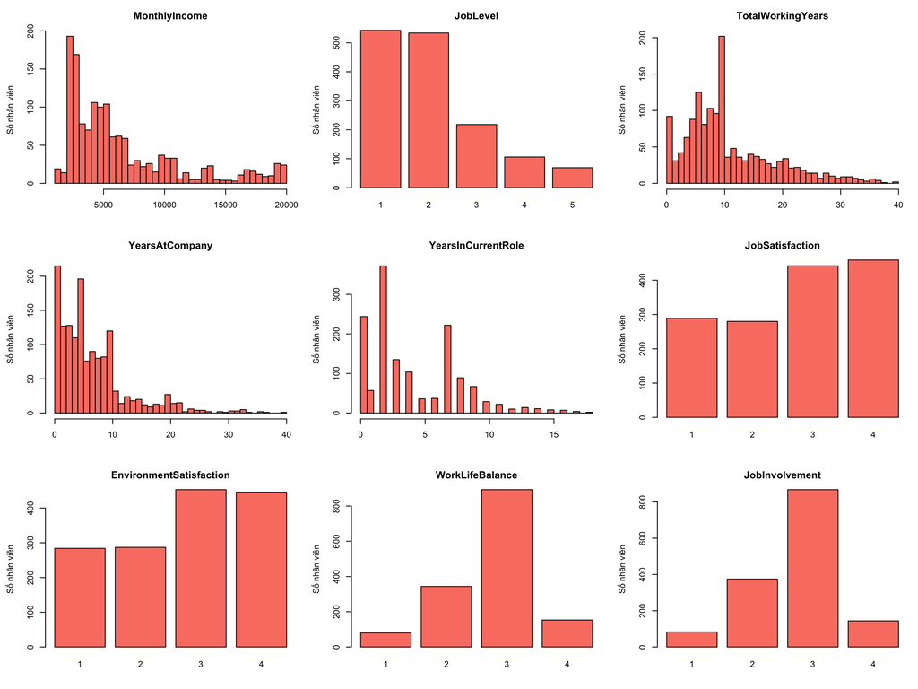

```r
par(mfrow = c(3, 3), mar = c(4, 4.5, 3, 1))
for (v in bien) {
  if (length(unique(ea_goc[[v]])) <= 5) {
    barplot(table(ea_goc[[v]]), main = v, col = "salmon", ylab = "Số nhân viên")   # biến thứ bậc
  } else {
    hist(ea_goc[[v]], breaks = 30, main = v, xlab = "", ylab = "Số nhân viên", col = "salmon")
  }
}
```

```r
par(mfrow = c(1, 1))
```

- Histogram của thu nhập và các biến số năm cho thấy phần lớn nhân viên có thu nhập thấp và thâm niên ngắn, một số ít có thu nhập hoặc thâm niên rất cao.
- **`JobLevel`** tập trung ở cấp 1–2, số nhân viên giảm dần ở các cấp cao (skew = 1.02).
- `JobSatisfaction` và `EnvironmentSatisfaction` có số nhân viên khá đều ở các mức (kurtosis ≈ −1.2, phân phối dẹt); `WorkLifeBalance` và `JobInvolvement` tập trung ở mức 3.
- `JobLevel` và 4 biến tâm lý – hành vi là **biến thứ bậc** có ít mức (4–5 mức), được xử lý như biến định lượng theo yêu cầu của đề.

Ràng buộc logic giữa các biến thời gian:

```r
# Ràng buộc logic giữa các biến về thời gian (số dòng vi phạm)
data.frame(
  rang_buoc = c("YearsInCurrentRole <= YearsAtCompany",
                "YearsAtCompany <= TotalWorkingYears",
                "TotalWorkingYears < Age"),
  so_dong_vi_pham = c(sum(ea_goc$YearsInCurrentRole > ea_goc$YearsAtCompany),
                      sum(ea_goc$YearsAtCompany > ea_goc$TotalWorkingYears),
                      sum(ea_goc$TotalWorkingYears >= ea_goc$Age))
)
```

| rang_buoc | so_dong_vi_pham |
| --- | --- |
| YearsInCurrentRole <= YearsAtCompany | 0 |
| YearsAtCompany <= TotalWorkingYears | 0 |
| TotalWorkingYears < Age | 0 |

Không có dòng nào vi phạm ràng buộc logic: số năm ở vị trí hiện tại không vượt số năm tại công ty, số năm tại công ty không vượt tổng số năm làm việc, và tổng số năm làm việc nhỏ hơn tuổi.

### 2.2.5 Giá trị ngoại lai từng biến

Ngoại lai một chiều được xác định theo quy tắc boxplot của Tukey (*Exploratory Data Analysis*, 1977): giá trị nằm ngoài khoảng $[Q_1 - 1.5\,IQR;\ Q_3 + 1.5\,IQR]$, với $IQR = Q_3 - Q_1$.

```r
ngoai_lai_1c <- function(x) {
  q <- quantile(x, c(0.25, 0.75)); iqr <- q[2] - q[1]
  x < q[1] - 1.5 * iqr | x > q[2] + 1.5 * iqr
}
data.frame(bien = bien,
           so_ngoai_lai = sapply(ea_goc[bien], function(x) sum(ngoai_lai_1c(x))),
           ty_le_pct    = round(sapply(ea_goc[bien], function(x) mean(ngoai_lai_1c(x))) * 100, 1),
           row.names = NULL)
```

| bien | so_ngoai_lai | ty_le_pct |
| --- | --- | --- |
| MonthlyIncome | 114 | 7.8 |
| JobLevel | 0 | 0.0 |
| TotalWorkingYears | 63 | 4.3 |
| YearsAtCompany | 104 | 7.1 |
| YearsInCurrentRole | 21 | 1.4 |
| JobSatisfaction | 0 | 0.0 |
| EnvironmentSatisfaction | 0 | 0.0 |
| WorkLifeBalance | 0 | 0.0 |
| JobInvolvement | 0 | 0.0 |

`MonthlyIncome` (114 giá trị, 7.8%), `YearsAtCompany` (104, 7.1%), `TotalWorkingYears` (63, 4.3%) và `YearsInCurrentRole` (21, 1.4%) có giá trị ngoại lai, đều ở phía trên do các biến này lệch phải. 5 biến thứ bậc không có ngoại lai.

**Kiểm tra tính hợp lý của các ngoại lai.** Một giá trị ngoại lai là hợp lý nếu nó phù hợp với các đặc điểm khác của chính nhân viên đó (tuổi, cấp bậc, thâm niên). Bảng dưới so sánh trung bình các đặc điểm liên quan giữa nhóm ngoại lai và nhóm còn lại, cho 4 biến có ngoại lai.

```r
bien_ho_so <- c("Age", "JobLevel", "MonthlyIncome", "TotalWorkingYears", "YearsAtCompany", "YearsInCurrentRole")
bien_co_nl <- c("MonthlyIncome", "TotalWorkingYears", "YearsAtCompany", "YearsInCurrentRole")
ho_so_nl <- do.call(rbind, lapply(bien_co_nl, function(v) {
  nl <- ngoai_lai_1c(ea_goc[[v]])
  rbind(data.frame(bien_xet = v, nhom = paste0("Ngoại lai (n = ", sum(nl), ")"),
                   t(colMeans(ea_goc[nl, bien_ho_so]))),
        data.frame(bien_xet = v, nhom = paste0("Còn lại (n = ", sum(!nl), ")"),
                   t(colMeans(ea_goc[!nl, bien_ho_so]))))
}))
bang(ho_so_nl, digits = 1, row.names = FALSE, soc = FALSE,
     col.names = c("Biến xét", "Nhóm", bien_ho_so)) |>
  to_xam(dong = grep("^Ngoại lai", ho_so_nl$nhom)) |>
  khong_ngat(cot = 1:2)
```

| Biến xét | Nhóm | Age | JobLevel | MonthlyIncome | TotalWorkingYears | YearsAtCompany | YearsInCurrentRole |
| --- | --- | --- | --- | --- | --- | --- | --- |
| MonthlyIncome | Ngoại lai (n = 114) | 47.5 | 4.6 | 18399.7 | 26.1 | 14.6 | 6.7 |
| MonthlyIncome | Còn lại (n = 1356) | 36.0 | 1.9 | 5502.8 | 10.0 | 6.4 | 4.0 |
| TotalWorkingYears | Ngoại lai (n = 63) | 53.4 | 4.2 | 15781.4 | 32.6 | 16.9 | 6.7 |
| TotalWorkingYears | Còn lại (n = 1407) | 36.2 | 2.0 | 6087.5 | 10.3 | 6.6 | 4.1 |
| YearsAtCompany | Ngoại lai (n = 104) | 45.7 | 4.0 | 14594.5 | 25.4 | 23.5 | 9.0 |
| YearsAtCompany | Còn lại (n = 1366) | 36.3 | 1.9 | 5886.9 | 10.2 | 5.8 | 3.9 |
| YearsInCurrentRole | Ngoại lai (n = 21) | 45.9 | 4.0 | 15260.4 | 25.0 | 21.5 | 16.0 |
| YearsInCurrentRole | Còn lại (n = 1449) | 36.8 | 2.0 | 6376.0 | 11.1 | 6.8 | 4.1 |

Ở cả 4 biến, nhóm ngoại lai (dòng xám) lớn tuổi hơn (45.7–53.4 so với 36.0–36.8 tuổi), cấp bậc cao hơn (4.0–4.6 so với 1.9–2.0), thu nhập cao hơn (14594–18400 so với 5503–6376) và tổng số năm làm việc dài hơn (25.0–32.6 so với 10.0–11.1 năm). Các giá trị ngoại lai đi cùng nhau trên cùng một nhóm nhân viên lâu năm, cấp cao.

```r
# Cấp bậc của các nhân viên có thu nhập ngoại lai
nl_thu_nhap <- ngoai_lai_1c(ea_goc$MonthlyIncome)
knitr::kable(table(JobLevel = ea_goc$JobLevel[nl_thu_nhap]), col.names = c("JobLevel", "Số nhân viên"))
```

| JobLevel | Số nhân viên |
| --- | --- |
| 4 | 45 |
| 5 | 69 |

Cả 114 nhân viên có thu nhập ngoại lai (trên 16581) đều ở cấp bậc 4–5: 45 người cấp 4 và toàn bộ 69 người cấp 5.

```r
# Vị trí công việc của các nhân viên có thu nhập ngoại lai
knitr::kable(table(JobRole = ea_goc$JobRole[nl_thu_nhap]), col.names = c("JobRole", "Số nhân viên"))
```

| JobRole | Số nhân viên |
| --- | --- |
| Manager | 74 |
| Research Director | 40 |

Họ đều giữ vị trí quản lý: `Manager` (74) hoặc `Research Director` (40), nên thu nhập cao là phù hợp với vị trí.

```r
# Khoảng thu nhập theo cấp bậc (toàn bộ dữ liệu)
thu_nhap_cap <- t(sapply(split(ea_goc$MonthlyIncome, ea_goc$JobLevel),
                         function(x) c(n = length(x), nho_nhat = min(x), trung_vi = median(x), lon_nhat = max(x))))
knitr::kable(data.frame(JobLevel = rownames(thu_nhap_cap), thu_nhap_cap), row.names = FALSE,
             caption = "MonthlyIncome theo JobLevel")
```

MonthlyIncome theo JobLevel

| JobLevel | n | nho_nhat | trung_vi | lon_nhat |
| --- | --- | --- | --- | --- |
| 1 | 543 | 1009 | 2670 | 4968 |
| 2 | 534 | 2042 | 5340 | 9998 |
| 3 | 218 | 5210 | 9980 | 13757 |
| 4 | 106 | 11103 | 16154 | 17924 |
| 5 | 69 | 18041 | 19232 | 19999 |

Thu nhập tăng rõ theo cấp bậc: trung vị 2670 ở cấp 1, 9980 ở cấp 3 và 19232 ở cấp 5; mọi nhân viên cấp 5 có thu nhập từ 18041 trở lên, nên thu nhập trên 16581 là mức bình thường của cấp 5.

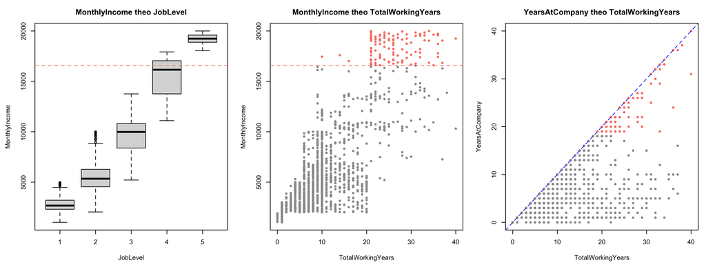

```r
q_tn <- quantile(ea_goc$MonthlyIncome, c(0.25, 0.75))
nguong_tn <- q_tn[2] + 1.5 * (q_tn[2] - q_tn[1])            # ngưỡng trên của thu nhập
nl_nam <- ngoai_lai_1c(ea_goc$YearsAtCompany)
par(mfrow = c(1, 3), mar = c(4.5, 4.5, 3, 1))

# (1) Thu nhập theo cấp bậc
boxplot(MonthlyIncome ~ JobLevel, data = ea_goc, col = "grey85",
        main = "MonthlyIncome theo JobLevel", xlab = "JobLevel", ylab = "MonthlyIncome")
abline(h = nguong_tn, col = "salmon", lty = 2)

# (2) Thu nhập theo tổng số năm làm việc
plot(ea_goc$TotalWorkingYears, ea_goc$MonthlyIncome, pch = 19, cex = 0.6,
     col = ifelse(nl_thu_nhap, "salmon", "grey60"),
     main = "MonthlyIncome theo TotalWorkingYears", xlab = "TotalWorkingYears", ylab = "MonthlyIncome")
abline(h = nguong_tn, col = "salmon", lty = 2)

# (3) Số năm tại công ty theo tổng số năm làm việc
plot(ea_goc$TotalWorkingYears, ea_goc$YearsAtCompany, pch = 19, cex = 0.6,
     col = ifelse(nl_nam, "salmon", "grey60"),
     main = "YearsAtCompany theo TotalWorkingYears", xlab = "TotalWorkingYears", ylab = "YearsAtCompany")
abline(0, 1, col = "blue", lty = 2)   # đường YearsAtCompany = TotalWorkingYears
```

```r
par(mfrow = c(1, 1))
```

- **Biểu đồ (1) và (2):** các điểm thu nhập ngoại lai (màu đỏ) nằm ở cấp bậc 4–5 và ở vùng nhiều năm kinh nghiệm; tương quan giữa thu nhập và tổng số năm làm việc là r = 0.77.
- **Biểu đồ (3):** nhân viên có `YearsAtCompany` ngoại lai (trên 18 năm) có tuổi từ 38 đến 60 và tổng số năm làm việc từ 19 đến 40; trung bình 93% sự nghiệp của họ là ở công ty này, nên các điểm nằm sát đường `YearsAtCompany = TotalWorkingYears`.

**Kết luận về ngoại lai:** các ngoại lai một chiều là những nhân viên lâu năm, lớn tuổi, cấp bậc và thu nhập cao; giá trị của chúng nhất quán với các biến khác của chính nhân viên đó và nằm trong miền hợp lệ, nên đây là quan sát thật chứ không phải lỗi nhập liệu. Các quan sát này được **giữ nguyên**: MANOVA so sánh vectơ trung bình, việc loại hay cắt (winsorize) chúng sẽ làm thay đổi chính các trung bình cần so sánh và bỏ đi nhóm nhân viên cấp cao. Ngoại lai nhiều chiều được xét ở mục 3.

## 2.3 Dữ liệu sau xử lý

```r
ea <- ea_goc[, c("EmployeeNumber", "Attrition", "OverTime", bien)]
ea$Attrition <- factor(ea$Attrition, levels = c("No", "Yes"))
ea$OverTime  <- factor(ea$OverTime,  levels = c("No", "Yes"))

# Ma trận dữ liệu cho MANOVA một nhân tố (9 biến) và hai nhân tố (4 biến tâm lý – hành vi)
X <- as.matrix(ea[, bien])
bien_tl <- c("JobSatisfaction", "EnvironmentSatisfaction", "WorkLifeBalance", "JobInvolvement")
Y <- as.matrix(ea[, bien_tl])

nhom <- ea$Attrition
X1 <- X[nhom == "No", ]    # nhân viên đang làm việc
X2 <- X[nhom == "Yes", ]   # nhân viên đã nghỉ việc
n  <- nrow(X); p <- ncol(X); g <- 2
n1 <- nrow(X1); n2 <- nrow(X2)
knitr::kable(t(c(n = n, p = p, n1 = n1, n2 = n2)))
```

| n | p | n1 | n2 |
| --- | --- | --- | --- |
| 1470 | 9 | 1233 | 237 |

```r
# 4 cặp của mô hình hai nhân tố
nhan_attrition <- c(No = "Working", Yes = "Left")
nhan_overtime  <- c(No = "NoOT", Yes = "OT")
o <- factor(paste(nhan_attrition[as.character(ea$Attrition)], nhan_overtime[as.character(ea$OverTime)], sep = "-"),
            levels = c("Working-NoOT", "Left-NoOT", "Working-OT", "Left-OT"))
knitr::kable(table(Attrition = ea$Attrition, OverTime = ea$OverTime))
```

|  | No | Yes |
| --- | --- | --- |
| No | 944 | 289 |
| Yes | 110 | 127 |

Dữ liệu sạch gồm 1470 nhân viên, 2 nhân tố và 9 biến định lượng. Các bước tạo dữ liệu này được gom vào `R/du_lieu.R` để các mục sau dùng chung. Cỡ mẫu **không cân bằng**: 1233 nhân viên đang làm việc và 237 nhân viên đã nghỉ việc; 4 cặp Attrition × OverTime có cỡ mẫu: `Working-NoOT` = 944, `Working-OT` = 289, `Left-NoOT` = 110, `Left-OT` = 127. Trong các bảng sau, nhóm `Attrition` được ký hiệu **Working** (đang làm việc, No) và **Left** (đã nghỉ việc, Yes), `OverTime` được ký hiệu **NoOT** (không làm thêm giờ, No) và **OT** (có làm thêm giờ, Yes); ví dụ `Left-NoOT` là nhân viên đã nghỉ việc và không làm thêm giờ.

## 2.4 Mô hình phân tích

**Mô hình:** MANOVA một nhân tố với g = 2 tổng thể (Johnson & Wichern, mục 6.4). Với hai tổng thể, MANOVA một nhân tố tương đương kiểm định Hotelling $T^2$ so sánh hai vectơ trung bình (Johnson & Wichern, mục 6.3).

- **Biến độc lập (nhân tố):** `Attrition`, 2 mức: No (đang làm việc, $\ell = 1$), Yes (đã nghỉ việc, $\ell = 2$).
- **Vectơ biến phụ thuộc** (p = 9):

$$\mathbf X = \big(\underbrace{\text{MonthlyIncome},\
\text{JobLevel}}_{\text{thu nhập – nghề nghiệp}},\
\underbrace{\text{TotalWorkingYears},\ \text{YearsAtCompany},\
\text{YearsInCurrentRole}}_{\text{kinh nghiệm}},\
\underbrace{\text{JobSatisfaction},\ \text{EnvironmentSatisfaction},\
\text{WorkLifeBalance},\ \text{JobInvolvement}}_{\text{tâm lý – hành
vi}}\big)'$$

- **Mô hình:** $\mathbf X_{\ell j} = \boldsymbol\mu + \boldsymbol\tau_\ell + \mathbf e_{\ell j}$, $j = 1, \dots, n_\ell$, $\ell = 1, 2$, với $n_1\boldsymbol\tau_1 + n_2\boldsymbol\tau_2 = \mathbf 0$ và $\mathbf e_{\ell j} \sim N_9(\mathbf 0, \boldsymbol\Sigma)$ độc lập.

**Giả thuyết kiểm định tổng thể:**

$$\begin{aligned}
H_0 &: \boldsymbol\mu_1 = \boldsymbol\mu_2 \\
H_A &: \boldsymbol\mu_1 \neq \boldsymbol\mu_2
\end{aligned}$$

hay tương đương

$$\begin{aligned}
H_0 &: \boldsymbol\tau_1 = \boldsymbol\tau_2 = \mathbf 0 \\
H_A &: \text{tồn tại } \boldsymbol\tau_\ell \neq \mathbf 0
\end{aligned}$$

trong đó $\boldsymbol\mu_1$, $\boldsymbol\mu_2$ là vectơ trung bình của 9 biến ở nhóm đang làm việc và nhóm đã nghỉ việc.

**Các giả định của MANOVA** (Johnson & Wichern, mục 6.4): (1) các mẫu độc lập với nhau và các quan sát trong mỗi mẫu độc lập; (2) mỗi tổng thể có phân phối chuẩn nhiều chiều; (3) các tổng thể có cùng ma trận hiệp phương sai $\boldsymbol\Sigma_1 = \boldsymbol\Sigma_2$. Giả định (1) được đảm bảo theo cách thu thập dữ liệu (mỗi dòng là một nhân viên khác nhau); giả định (2) và (3) được kiểm tra ở mục 3.

# 3 Kiểm tra chuẩn đa biến và đồng nhất ma trận hiệp phương sai

Giả định được kiểm tra cho cả hai mô hình:

- **MANOVA một nhân tố:** 9 biến, trong từng nhóm `Attrition` (2 nhóm).
- **MANOVA hai nhân tố:** 4 biến tâm lý – hành vi, trong từng cặp `Attrition × OverTime` (4 cặp), vì mô hình hai nhân tố giả định mỗi cặp là một tổng thể chuẩn 4 chiều và các cặp có cùng ma trận hiệp phương sai.

Với mô hình một nhân tố, `MonthlyIncome` và `JobLevel` có đa cộng tuyến (mục Tương quan và đa cộng tuyến), nên mô hình được xét theo hai kịch bản: **kịch bản 1** giữ `MonthlyIncome` (9 biến) và **kịch bản 2** bỏ `MonthlyIncome` (8 biến). Bỏ một biến chỉ làm thay đổi các kiểm tra tính trên cả vectơ biến (ngoại lai Mahalanobis, tương quan – VIF, chuẩn nhiều chiều, Box’s M), nên chỉ các kiểm tra này được làm cho cả hai kịch bản; các kiểm tra từng biến (thống kê mô tả, Shapiro-Wilk, Levene) cho kết quả như nhau ở 8 biến chung.

## 3.1 Thống kê mô tả

Trong các bảng và biểu đồ, nhóm `Attrition` được ký hiệu **Working** (đang làm việc, Attrition = No) và **Left** (đã nghỉ việc, Attrition = Yes); `OverTime` được ký hiệu **NoOT** (không làm thêm giờ) và **OT** (có làm thêm giờ). 4 cặp của mô hình hai nhân tố là `Working-NoOT`, `Left-NoOT`, `Working-OT`, `Left-OT`.

Phần này mô tả từng biến phụ thuộc theo nhân tố trước khi kiểm tra giả định: theo `Attrition` cho MANOVA một nhân tố (9 biến), và theo từng cặp `Attrition × OverTime` cho MANOVA hai nhân tố (4 biến tâm lý – hành vi).

### 3.1.1 Mô tả chung

```r
mo_ta_chung <- t(sapply(as.data.frame(X), function(x) c(summary(x), "Độ lệch chuẩn" = sd(x))))
bang(mo_ta_chung, digits = 2, col.names = c("Nhỏ nhất", "Q1", "Trung vị", "Trung bình", "Q3", "Lớn nhất", "Độ lệch chuẩn"))
```

|  | Nhỏ nhất | Q1 | Trung vị | Trung bình | Q3 | Lớn nhất | Độ lệch chuẩn |
| --- | --- | --- | --- | --- | --- | --- | --- |
| MonthlyIncome | 1009 | 2911 | 4919 | 6502.93 | 8379 | 19999 | 4707.96 |
| JobLevel | 1 | 1 | 2 | 2.06 | 3 | 5 | 1.11 |
| TotalWorkingYears | 0 | 6 | 10 | 11.28 | 15 | 40 | 7.78 |
| YearsAtCompany | 0 | 3 | 5 | 7.01 | 9 | 40 | 6.13 |
| YearsInCurrentRole | 0 | 2 | 3 | 4.23 | 7 | 18 | 3.62 |
| JobSatisfaction | 1 | 2 | 3 | 2.73 | 4 | 4 | 1.10 |
| EnvironmentSatisfaction | 1 | 2 | 3 | 2.72 | 4 | 4 | 1.09 |
| WorkLifeBalance | 1 | 2 | 3 | 2.76 | 3 | 4 | 0.71 |
| JobInvolvement | 1 | 2 | 3 | 2.73 | 3 | 4 | 0.71 |

### 3.1.2 Một nhân tố (9 biến, theo Attrition)

Với mỗi biến, bảng dưới cho trung bình, trung vị, độ lệch chuẩn ở từng nhóm, chênh lệch trung bình (Left − Working) và chênh lệch chuẩn hóa

$$d = \frac{\bar x_{2} - \bar x_{1}}{s_{gộp}}, \qquad s_{gộp}^2 =
\frac{(n_1 - 1)s_1^2 + (n_2 - 1)s_2^2}{n_1 + n_2 - 2},$$

trong đó, với một biến cụ thể (ví dụ `MonthlyIncome`):

- $\bar x_1$, $s_1^2$: trung bình và phương sai mẫu của biến ở nhóm Working ($n_1 = 1233$ nhân viên);
- $\bar x_2$, $s_2^2$: trung bình và phương sai mẫu của biến ở nhóm Left ($n_2 = 237$ nhân viên);
- $s_{gộp}^2$: phương sai gộp, là trung bình có trọng số (theo bậc tự do $n_\ell - 1$) của phương sai hai nhóm, ước lượng phương sai chung trong nhóm của biến.

$d$ cho biết trung bình nhóm Left lệch bao nhiêu **độ lệch chuẩn** so với nhóm Working ($d < 0$: nhóm Left thấp hơn). Vì không phụ thuộc đơn vị đo, $d$ cho phép so sánh mức chênh lệch giữa thu nhập (đơn vị tiền), số năm và thang điểm 1–4.

```r
mo_ta_A <- do.call(rbind, lapply(bien, function(v) {
  x0 <- ea[[v]][nhom == "No"]; x1 <- ea[[v]][nhom == "Yes"]
  s_gop <- sqrt(((n1 - 1) * var(x0) + (n2 - 1) * var(x1)) / (n - 2))
  data.frame(bien = v,
             tb_No = mean(x0), tv_No = median(x0), dlc_No = sd(x0),
             tb_Yes = mean(x1), tv_Yes = median(x1), dlc_Yes = sd(x1),
             chenh_tb = mean(x1) - mean(x0),
             chenh_chuan_hoa = (mean(x1) - mean(x0)) / s_gop)
}))
bang(mo_ta_A, digits = 2, row.names = FALSE,
     col.names = c("Biến", "TB", "Trung vị", "ĐLC", "TB", "Trung vị", "ĐLC", "Chênh lệch TB", "Chênh lệch chuẩn hóa")) |>
  them_tieu_de(header = c(" " = 1, "Working" = 3, "Left" = 3, "Left − Working" = 2))
```

| Biến | TB | Trung vị | ĐLC | TB | Trung vị | ĐLC | Chênh lệch TB | Chênh lệch chuẩn hóa |
| --- | --- | --- | --- | --- | --- | --- | --- | --- |
| MonthlyIncome | 6832.74 | 5204 | 4818.21 | 4787.09 | 3202 | 3640.21 | -2045.65 | -0.44 |
| JobLevel | 2.15 | 2 | 1.12 | 1.64 | 1 | 0.94 | -0.51 | -0.47 |
| TotalWorkingYears | 11.86 | 10 | 7.76 | 8.24 | 7 | 7.17 | -3.62 | -0.47 |
| YearsAtCompany | 7.37 | 6 | 6.10 | 5.13 | 3 | 5.95 | -2.24 | -0.37 |
| YearsInCurrentRole | 4.48 | 3 | 3.65 | 2.90 | 2 | 3.17 | -1.58 | -0.44 |
| JobSatisfaction | 2.78 | 3 | 1.09 | 2.47 | 3 | 1.12 | -0.31 | -0.28 |
| EnvironmentSatisfaction | 2.77 | 3 | 1.07 | 2.46 | 3 | 1.17 | -0.31 | -0.28 |
| WorkLifeBalance | 2.78 | 3 | 0.68 | 2.66 | 3 | 0.82 | -0.12 | -0.17 |
| JobInvolvement | 2.77 | 3 | 0.69 | 2.52 | 3 | 0.77 | -0.25 | -0.36 |

- Nhóm đã nghỉ việc có trung bình **thấp hơn ở cả 9 biến**. Chênh lệch chuẩn hóa từ −0.17 (`WorkLifeBalance`) đến −0.47 (`TotalWorkingYears`, `JobLevel`): khác biệt lớn nhất nằm ở thu nhập – nghề nghiệp và kinh nghiệm (−0.37 đến −0.47), nhỏ hơn ở các biến tâm lý – hành vi (−0.17 đến −0.36).
- **Thu nhập:** trung bình 4787 so với 6833 (trung vị 3202 so với 5204). **Kinh nghiệm:** tổng số năm làm việc 8.24 so với 11.86, số năm tại công ty 5.13 so với 7.37 (trung vị 3 so với 6), số năm ở vị trí hiện tại 2.90 so với 4.48.
- **Tâm lý – hành vi:** trung bình của nhóm nghỉ việc thấp hơn 0.12–0.31 điểm trên thang 1–4, trung vị bằng nhau (3) ở cả hai nhóm.
- Độ lệch chuẩn của thu nhập và cấp bậc ở nhóm đang làm việc lớn hơn nhóm nghỉ việc (4818 so với 3640; 1.12 so với 0.94), trong khi 4 biến tâm lý – hành vi có độ lệch chuẩn lớn hơn ở nhóm nghỉ việc; đây là dấu hiệu ban đầu của phương sai không đồng nhất, được kiểm tra bằng Levene và Box’s M ở dưới.

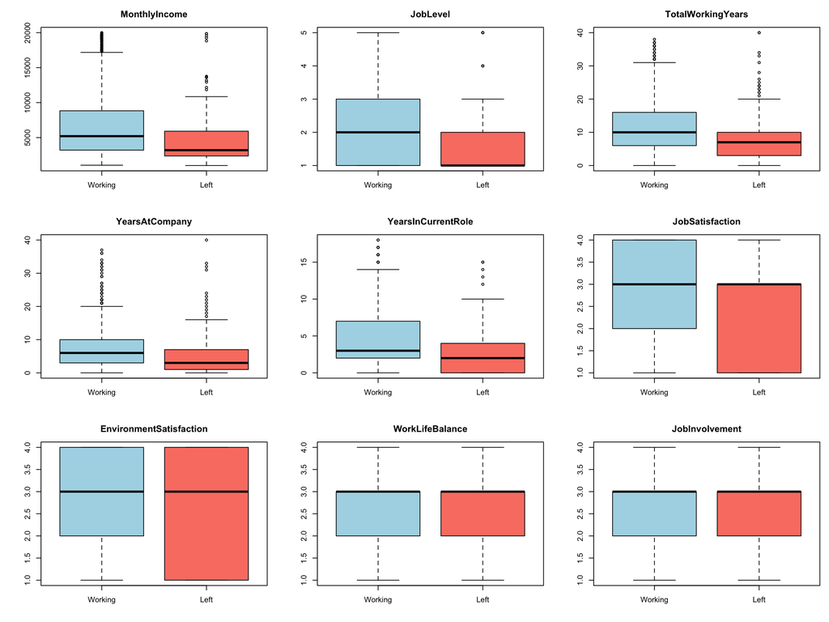

```r
par(mfrow = c(3, 3), mar = c(4, 4.5, 3, 1))
for (v in bien) {
  boxplot(ea[[v]] ~ nhom_nhan, col = c("lightblue", "salmon"),
          main = v, xlab = "", ylab = "")
}
```

```r
par(mfrow = c(1, 1))
```

Hộp của nhóm Left nằm thấp hơn nhóm Working ở thu nhập và 3 biến số năm, với nhiều điểm ngoại lai phía trên ở cả hai nhóm do phân phối lệch phải. Ở `JobLevel`, trung vị nhóm Left là cấp 1 so với cấp 2 ở nhóm Working. Ở 4 biến tâm lý – hành vi, trung vị hai nhóm cùng bằng 3; hộp của nhóm Left kéo xuống mức 1 ở `JobSatisfaction` và `EnvironmentSatisfaction`, còn `WorkLifeBalance`, `JobInvolvement` có hộp trùng nhau vì biến chỉ có 4 mức.

`JobLevel` và 4 biến tâm lý – hành vi là biến thứ bậc chỉ có 4–5 mức, nên boxplot không thể hiện đủ phân phối; bảng và biểu đồ dưới cho tỷ lệ (%) nhân viên ở từng mức, theo nhóm.

```r
bien_thu_bac <- c("JobLevel", bien_tl)
ty_le_A <- do.call(rbind, lapply(bien_thu_bac, function(v) {
  tl <- round(prop.table(table(ea$Attrition, factor(ea[[v]], levels = 1:5)), 1) * 100, 1)
  data.frame(bien = v, nhom = nhan_attrition[rownames(tl)], as.data.frame.matrix(tl), check.names = FALSE, row.names = NULL)
}))
ty_le_A$`5`[ty_le_A$bien != "JobLevel"] <- NA   # 4 biến tâm lý – hành vi chỉ có mức 1–4
options(knitr.kable.NA = "")
bang(ty_le_A, digits = 1, row.names = FALSE, col.names = c("Biến", "Nhóm", "Mức 1", "Mức 2", "Mức 3", "Mức 4", "Mức 5")) |>
  them_tieu_de(header = c(" " = 2, "Tỷ lệ (%) trong nhóm" = 5)) |>
  gop_dong(cot = 1)
```

| Biến | Nhóm | Mức 1 | Mức 2 | Mức 3 | Mức 4 | Mức 5 |
| --- | --- | --- | --- | --- | --- | --- |
| JobLevel | Working | 32.4 | 39.1 | 15.1 | 8.2 | 5.2 |
| JobLevel | Left | 60.3 | 21.9 | 13.5 | 2.1 | 2.1 |
| JobSatisfaction | Working | 18.1 | 19.0 | 29.9 | 33.0 |  |
| JobSatisfaction | Left | 27.8 | 19.4 | 30.8 | 21.9 |  |
| EnvironmentSatisfaction | Working | 17.2 | 19.8 | 31.7 | 31.3 |  |
| EnvironmentSatisfaction | Left | 30.4 | 18.1 | 26.2 | 25.3 |  |
| WorkLifeBalance | Working | 4.5 | 23.2 | 62.1 | 10.2 |  |
| WorkLifeBalance | Left | 10.5 | 24.5 | 53.6 | 11.4 |  |
| JobInvolvement | Working | 4.5 | 24.7 | 60.3 | 10.6 |  |
| JobInvolvement | Left | 11.8 | 30.0 | 52.7 | 5.5 |  |

- 60.3% nhân viên nghỉ việc ở cấp bậc 1, so với 32.4% ở nhóm đang làm việc.
- Tỷ lệ chọn mức 1 ở nhóm nghỉ việc cao hơn nhóm đang làm việc với hài lòng công việc (27.8% so với 18.1%), hài lòng môi trường (30.4% so với 17.2%), cân bằng công việc – cuộc sống (10.5% so với 4.5%) và mức độ tham gia công việc (11.8% so với 4.5%): khác biệt ở các biến tâm lý – hành vi thể hiện rõ ở mức thấp nhất của thang đo.

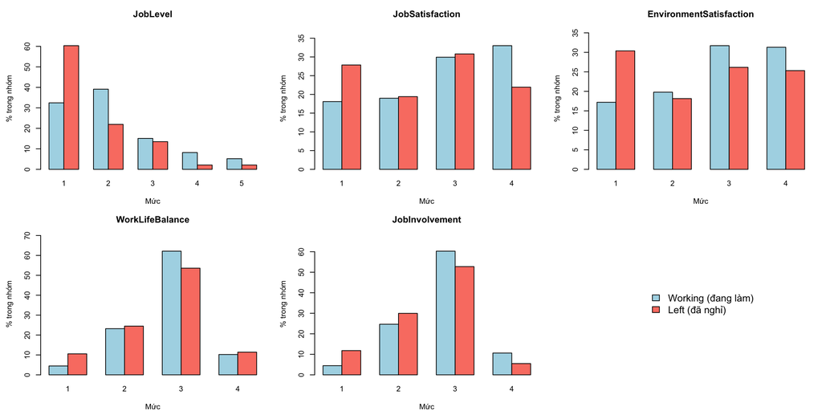

```r
par(mfrow = c(2, 3), mar = c(4, 4.5, 3, 1))
for (v in bien_thu_bac) {
  tl <- prop.table(table(ea$Attrition, ea[[v]]), 1) * 100
  barplot(tl, beside = TRUE, col = c("lightblue", "salmon"), main = v,
          xlab = "Mức", ylab = "% trong nhóm", ylim = c(0, max(tl) * 1.15))
}
plot.new()
legend("center", legend = c("Working (đang làm)", "Left (đã nghỉ)"),
       fill = c("lightblue", "salmon"), bty = "n", cex = 1.3)
```

```r
par(mfrow = c(1, 1))
```

Biểu đồ cho cùng kết luận với bảng: cột đỏ (Left) cao hơn ở cấp bậc 1 và ở mức 1 của 4 thang tâm lý – hành vi, thấp hơn ở các mức cao.

### 3.1.3 Hai nhân tố (4 biến tâm lý – hành vi, theo Attrition × OverTime)

```r
# Cỡ mẫu và tỷ lệ nghỉ việc theo OverTime
bang_o <- table(nhom_nhan, nhan_overtime[as.character(ea$OverTime)])
ty_le_nghi <- round(prop.table(bang_o, 2) * 100, 1)       # % theo cột (trong từng mức OverTime)
bang_o2 <- cbind(as.data.frame.matrix(bang_o), as.data.frame.matrix(ty_le_nghi))
bang(bang_o2, digits = 1, col.names = c("NoOT", "OT", "NoOT", "OT")) |>
  them_tieu_de(header = c(" " = 1, "Số nhân viên" = 2, "Tỷ lệ (%) trong mức OverTime" = 2))
```

|  | NoOT | OT | NoOT | OT |
| --- | --- | --- | --- | --- |
| Working | 944 | 289 | 89.6 | 69.5 |
| Left | 110 | 127 | 10.4 | 30.5 |

Cỡ mẫu 4 cặp không cân bằng (110 đến 944). Tỷ lệ nghỉ việc ở nhóm làm thêm giờ (30.5%) cao gấp khoảng 3 lần nhóm không làm thêm giờ (10.4%), tức hai nhân tố không độc lập với nhau trong mẫu; vì vậy tác động riêng của từng nhân tố cần được đánh giá khi đã tính đến nhân tố còn lại (tổng bình phương loại II trong `car::Manova`, dùng ở mục 7).

```r
# Trung bình và độ lệch chuẩn từng biến trong 4 cặp
mo_ta_B <- t(sapply(bien_tl, function(v)
  sprintf("%.2f (%.2f)", tapply(ea[[v]], o, mean), tapply(ea[[v]], o, sd))))
colnames(mo_ta_B) <- paste0(levels(o), " (n = ", table(o), ")")
bang(mo_ta_B, caption = "Trung bình (độ lệch chuẩn) theo cặp")
```

Trung bình (độ lệch chuẩn) theo cặp

|  | Working-NoOT (n = 944) | Left-NoOT (n = 110) | Working-OT (n = 289) | Left-OT (n = 127) |
| --- | --- | --- | --- | --- |
| JobSatisfaction | 2.75 (1.08) | 2.36 (1.14) | 2.87 (1.13) | 2.56 (1.10) |
| EnvironmentSatisfaction | 2.71 (1.09) | 2.33 (1.17) | 2.96 (0.98) | 2.58 (1.16) |
| WorkLifeBalance | 2.79 (0.69) | 2.63 (0.89) | 2.75 (0.66) | 2.69 (0.75) |
| JobInvolvement | 2.76 (0.69) | 2.48 (0.80) | 2.80 (0.69) | 2.55 (0.75) |

- Ở cả hai mức `OverTime`, nhóm nghỉ việc có trung bình thấp hơn nhóm đang làm việc ở cả 4 biến; ví dụ hài lòng công việc 2.36 so với 2.75 (không làm thêm giờ) và 2.56 so với 2.87 (có làm thêm giờ), hài lòng môi trường 2.33 so với 2.71 và 2.58 so với 2.96.
- Độ lệch chuẩn trong cặp dao động 0.66–1.17; cặp `Left-NoOT` có độ lệch chuẩn lớn nhất ở `WorkLifeBalance` (0.89) và `JobInvolvement` (0.80), phù hợp với kết quả Levene ở dưới.

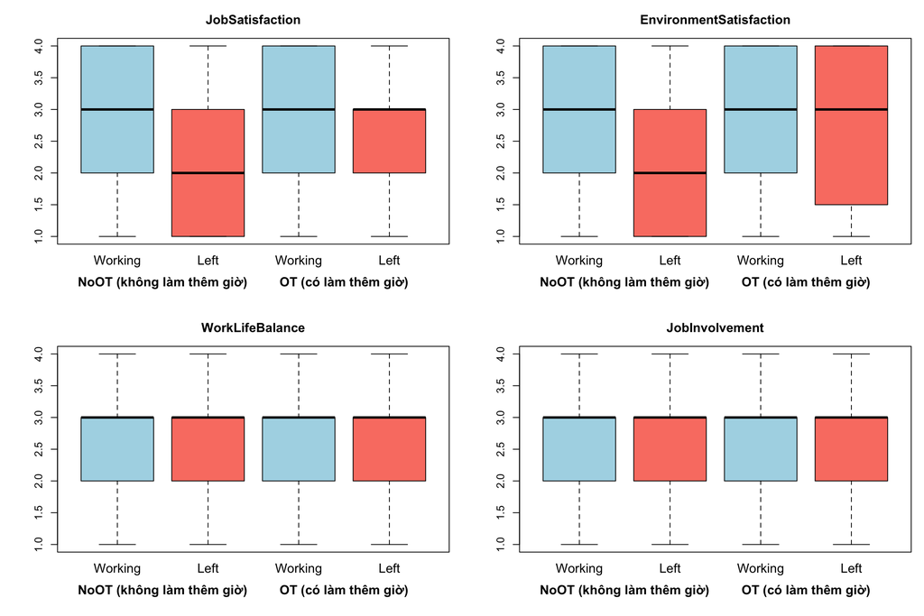

```r
par(mfrow = c(2, 2), mar = c(5, 4.5, 3, 1))
for (v in bien_tl) {
  boxplot(ea[[v]] ~ ea$Attrition + ea$OverTime, col = c("lightblue", "salmon"),
          xaxt = "n", main = v, xlab = "", ylab = "")
  mtext(rep(c("Working", "Left"), 2), side = 1, line = 0.8, at = 1:4)
  mtext(c("NoOT (không làm thêm giờ)", "OT (có làm thêm giờ)"), side = 1, line = 2.5, at = c(1.5, 3.5), font = 2)
}
```

```r
par(mfrow = c(1, 1))
```

Biểu đồ tương tác (profile plot) dưới vẽ trung bình của từng biến theo `OverTime`, mỗi đường là một mức `Attrition`. Hai đường song song gợi ý không có tương tác; hai đường không song song (cắt nhau hoặc khoảng cách thay đổi) gợi ý có tương tác, sẽ được kiểm định ở mục 7.

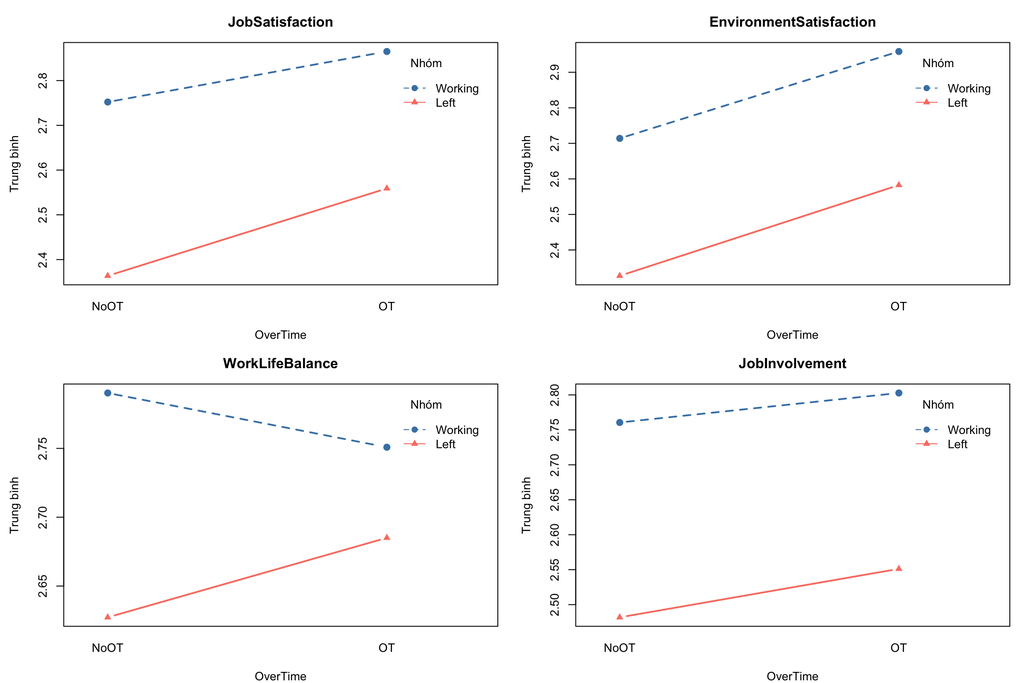

```r
par(mfrow = c(2, 2), mar = c(4, 4.5, 3, 1))
for (v in bien_tl) {
  interaction.plot(factor(nhan_overtime[as.character(ea$OverTime)], levels = c("NoOT", "OT")), nhom_nhan, ea[[v]],
                   type = "b", pch = c(19, 17), col = c("steelblue", "salmon"), lwd = 2, main = v,
                   xlab = "OverTime", ylab = "Trung bình", trace.label = "Nhóm")
}
```

```r
par(mfrow = c(1, 1))
```

Với `JobSatisfaction`, `EnvironmentSatisfaction` và `JobInvolvement`, hai đường gần song song (khoảng cách giữa hai nhóm Attrition 0.25–0.39 ở cả hai mức `OverTime`). Với `WorkLifeBalance`, khoảng cách thu hẹp từ 0.16 (không làm thêm giờ) xuống 0.06 (có làm thêm giờ), gợi ý có thể có tương tác ở biến này.

## 3.2 Ngoại lai nhiều chiều (khoảng cách Mahalanobis)

Với mỗi nhóm (mô hình một nhân tố) hoặc mỗi cặp (mô hình hai nhân tố), tính bình phương khoảng cách Mahalanobis của từng nhân viên đến tâm của nhóm (Johnson & Wichern, mục 4.6–4.7):

$$d_j^2 = (\mathbf x_j - \bar{\mathbf
x})' \mathbf S^{-1} (\mathbf x_j - \bar{\mathbf x}), \qquad j = 1,
\dots, n_\ell,$$

trong đó:

- $\mathbf x_j$: vectơ $p \times 1$ các giá trị của nhân viên thứ $j$. Với mô hình một nhân tố, $p = 9$ và $\mathbf x_j = (\text{MonthlyIncome}_j, \text{JobLevel}_j, \dots, \text{JobInvolvement}_j)'$; với mô hình hai nhân tố, $p = 4$ gồm 4 biến tâm lý – hành vi.
- $\bar{\mathbf x}$: vectơ trung bình mẫu của nhóm (cặp) chứa nhân viên đó, mỗi thành phần là trung bình của một biến trong nhóm.
- $\mathbf S$: ma trận hiệp phương sai mẫu $p \times p$ của nhóm (cặp). Phần tử trên đường chéo $s_{kk}$ là phương sai của biến $k$; phần tử ngoài đường chéo $s_{ik}$ là hiệp phương sai giữa biến $i$ và biến $k$.
- $\mathbf S^{-1}$: nghịch đảo của $\mathbf S$. Nhân với $\mathbf S^{-1}$ vừa chia mỗi độ lệch cho độ phân tán của biến (nên thu nhập tính bằng tiền và thang điểm 1–4 được đưa về cùng thang), vừa trừ phần trùng lặp do các biến tương quan với nhau (ví dụ thu nhập và cấp bậc).

$d_j^2$ là khoảng cách “chuẩn hóa” từ nhân viên $j$ đến tâm nhóm: $d_j^2$ lớn nghĩa là tổ hợp giá trị của nhân viên đó hiếm gặp so với phần còn lại của nhóm, kể cả khi từng giá trị riêng lẻ không bất thường. Nếu dữ liệu có phân phối chuẩn $p$ chiều thì $d_j^2$ có phân phối xấp xỉ $\chi^2_p$.

**Biểu đồ chi-bình phương:** sắp xếp $d^2_{(1)} \le \dots \le d^2_{(n)}$ và vẽ theo phân vị lý thuyết $q_{(j)} = \chi^2_p\big((j - \tfrac12)/n\big)$. Nếu dữ liệu chuẩn, các điểm nằm quanh đường thẳng $y = x$; các điểm cao vọt ở đầu phải là ngoại lai.

Với mỗi quan sát, kiểm định giả thuyết

$$\begin{aligned}
H_0 &: \text{quan sát } j \text{ không phải ngoại lai} \\
H_A &: \text{quan sát } j \text{ là ngoại lai}
\end{aligned}$$

Theo Johnson & Wichern (mục 4.7), $d_j^2$ “lớn” được đánh giá bằng một phân vị của phân phối $\chi^2_p$; vì ngay cả khi dữ liệu chuẩn vẫn có khoảng 5% số quan sát vượt phân vị 95%, nên cần dùng một phân vị cực trị hơn. Bài này chọn mức ý nghĩa α = 0.001, tức bác bỏ $H_0$ khi $d_j^2 > \chi^2_p(0.999)$.

```r
# Hàm tính d2 trong từng nhóm (cặp)
d2_theo_nhom <- function(M, f) {
  d2 <- numeric(nrow(M))
  for (l in levels(f)) {
    i <- which(f == l)
    d2[i] <- mahalanobis(M[i, ], colMeans(M[i, ]), cov(M[i, ]))
  }
  d2
}
# Bảng tổng hợp quan sát xa nhất của mỗi nhóm (cặp)
bang_ngoai_lai <- function(d2, f, df) {
  nguong <- qchisq(0.999, df = df)
  kq <- data.frame(nhom = levels(f),
                   n = as.vector(table(f)),
                   d2_lon_nhat = round(tapply(d2, f, max), 2),
                   p_value = fp(pchisq(tapply(d2, f, max), df = df, lower.tail = FALSE)),
                   nguong = round(nguong, 2),
                   so_ngoai_lai = as.vector(tapply(d2 > nguong, f, sum)),
                   row.names = NULL)
  bang(kq, row.names = FALSE,
       col.names = c("Nhóm", "n", "d² lớn nhất", "p-giá trị", paste0("Ngưỡng χ²", df, "(0.999)"), "Số ngoại lai"))
}
```

### 3.2.1 Một nhân tố – kịch bản 1 (giữ MonthlyIncome, 9 biến)

```r
d2_A <- d2_theo_nhom(X, nhom)
bang_ngoai_lai(d2_A, nhom_nhan, df = 9)
```

| Nhóm | n | d² lớn nhất | p-giá trị | Ngưỡng χ²9(0.999) | Số ngoại lai |
| --- | --- | --- | --- | --- | --- |
| Working | 1233 | 54.21 | 1.72e-08 | 27.88 | 17 |
| Left | 237 | 62.79 | 3.87e-10 | 27.88 | 6 |

Với ngưỡng $\chi^2_9(0.999) = 27.88$, nhóm Working có 17 quan sát vượt ngưỡng ($d^2$ lớn nhất 54.21, p-giá trị = 1.72e-08), nhóm Left có 6 quan sát ($d^2$ lớn nhất 62.79, p-giá trị = 3.87e-10). Với 23 quan sát này, p-giá trị < 0.001 nên ta bác bỏ $H_0$ với mức ý nghĩa 0.1%, nghĩa là đây là các quan sát ngoại lai nhiều chiều (1.6% mẫu).

```r
# Thông tin các quan sát ngoại lai
ngoai_lai_A <- which(d2_A > qchisq(0.999, df = 9))
ds_ngoai_lai <- data.frame(dong = ngoai_lai_A, ea[ngoai_lai_A, c("EmployeeNumber", bien)],
                           nhom = nhom_nhan[ngoai_lai_A], d2 = round(d2_A[ngoai_lai_A], 2), row.names = NULL)
bang(ds_ngoai_lai, row.names = FALSE) |>
  cuon(cao = "320px")
```

| dong | EmployeeNumber | MonthlyIncome | JobLevel | TotalWorkingYears | YearsAtCompany | YearsInCurrentRole | JobSatisfaction | EnvironmentSatisfaction | WorkLifeBalance | JobInvolvement | nhom | d2 |
| --- | --- | --- | --- | --- | --- | --- | --- | --- | --- | --- | --- | --- |
| 34 | 42 | 2086 | 2 | 19 | 1 | 0 | 4 | 4 | 4 | 3 | Left | 32.09 |
| 51 | 64 | 5381 | 3 | 23 | 1 | 0 | 3 | 1 | 3 | 2 | Left | 32.60 |
| 63 | 80 | 18740 | 5 | 29 | 27 | 3 | 3 | 2 | 2 | 2 | Working | 31.30 |
| 86 | 112 | 7260 | 3 | 37 | 6 | 4 | 4 | 4 | 2 | 1 | Working | 42.69 |
| 99 | 131 | 13872 | 4 | 38 | 37 | 10 | 3 | 4 | 2 | 3 | Working | 41.98 |
| 127 | 165 | 10312 | 3 | 40 | 40 | 10 | 4 | 4 | 2 | 3 | Left | 62.79 |
| 238 | 329 | 19068 | 5 | 33 | 33 | 7 | 3 | 1 | 4 | 2 | Working | 38.09 |
| 245 | 336 | 19202 | 5 | 25 | 24 | 0 | 4 | 3 | 3 | 4 | Working | 40.54 |
| 271 | 374 | 19045 | 5 | 37 | 36 | 10 | 1 | 4 | 3 | 3 | Working | 35.51 |
| 312 | 425 | 5210 | 3 | 24 | 24 | 9 | 1 | 1 | 3 | 3 | Working | 28.58 |
| 412 | 549 | 19566 | 5 | 33 | 29 | 8 | 1 | 1 | 1 | 3 | Working | 30.81 |
| 478 | 644 | 18200 | 5 | 32 | 32 | 5 | 2 | 1 | 3 | 3 | Working | 38.38 |
| 562 | 776 | 16856 | 4 | 34 | 34 | 6 | 1 | 3 | 4 | 2 | Working | 47.34 |
| 569 | 787 | 19859 | 5 | 24 | 5 | 2 | 1 | 4 | 3 | 3 | Left | 37.27 |
| 654 | 905 | 17924 | 4 | 31 | 31 | 6 | 1 | 1 | 3 | 3 | Working | 38.36 |
| 750 | 1038 | 19845 | 5 | 33 | 32 | 14 | 4 | 1 | 3 | 1 | Left | 31.03 |
| 915 | 1278 | 13577 | 4 | 34 | 33 | 9 | 2 | 4 | 3 | 2 | Working | 31.23 |
| 963 | 1352 | 14026 | 4 | 33 | 33 | 9 | 2 | 3 | 3 | 3 | Working | 28.43 |
| 1087 | 1539 | 14411 | 4 | 32 | 32 | 6 | 4 | 3 | 3 | 1 | Working | 39.66 |
| 1112 | 1572 | 10169 | 3 | 34 | 33 | 7 | 4 | 3 | 3 | 2 | Left | 45.83 |
| 1117 | 1578 | 19586 | 5 | 36 | 36 | 6 | 4 | 3 | 3 | 2 | Working | 46.31 |
| 1136 | 1602 | 17567 | 4 | 27 | 26 | 0 | 1 | 4 | 1 | 4 | Working | 54.21 |
| 1139 | 1606 | 11245 | 4 | 32 | 30 | 8 | 3 | 2 | 3 | 3 | Working | 29.31 |

Phần lớn các quan sát này là nhân viên có thâm niên rất dài (tổng số năm làm việc 24–40), nhiều người có thu nhập và cấp bậc cao (cấp 4–5); số còn lại có tổ hợp ít gặp như nhiều năm kinh nghiệm nhưng mới vào công ty (dòng 34 và 51: 19 và 23 năm làm việc, 1 năm tại công ty). Mọi giá trị đều hợp lệ và thỏa ràng buộc logic ở mục 2, nên các quan sát được **giữ lại**.

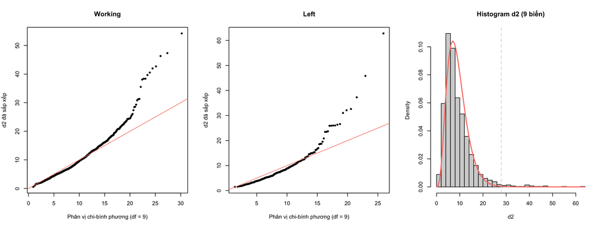

```r
par(mfrow = c(1, 3))
for (l in levels(nhom)) {
  d2 <- sort(d2_A[nhom == l]); m <- length(d2)
  plot(qchisq(((1:m) - 0.5) / m, df = 9), d2, pch = 19, cex = 0.6,
       main = nhan_attrition[l], xlab = "Phân vị chi-bình phương (df = 9)", ylab = "d2 đã sắp xếp")
  abline(0, 1, col = "salmon")
}
hist(d2_A, freq = FALSE, breaks = 40, main = "Histogram d2 (9 biến)", xlab = "d2")
curve(dchisq(x, df = 9), add = TRUE, col = "salmon", lwd = 2)
abline(v = qchisq(0.999, df = 9), col = "lightblue", lty = 2)
```

```r
par(mfrow = c(1, 1))
```

Trên biểu đồ chi-bình phương, các điểm lệch lên khỏi đường thẳng ở phần đuôi phải, và histogram $d^2$ có đuôi dài hơn mật độ $\chi^2_9$: phân phối có đuôi nặng hơn chuẩn, phù hợp với tính lệch phải của thu nhập và số năm làm việc.

### 3.2.2 Một nhân tố – kịch bản 2 (bỏ MonthlyIncome, 8 biến)

```r
d2_kb2 <- d2_theo_nhom(X_kb2, nhom)
bang_ngoai_lai(d2_kb2, nhom_nhan, df = 8)
```

| Nhóm | n | d² lớn nhất | p-giá trị | Ngưỡng χ²8(0.999) | Số ngoại lai |
| --- | --- | --- | --- | --- | --- |
| Working | 1233 | 51.19 | 2.41e-08 | 26.12 | 16 |
| Left | 237 | 62.53 | 1.48e-10 | 26.12 | 5 |

Với ngưỡng $\chi^2_8(0.999) = 26.12$, nhóm Working có 16 quan sát vượt ngưỡng ($d^2$ lớn nhất 51.19, p-giá trị = 2.41e-08), nhóm Left có 5 quan sát ($d^2$ lớn nhất 62.53, p-giá trị = 1.48e-10). Với 21 quan sát này, p-giá trị < 0.001 nên ta bác bỏ $H_0$ với mức ý nghĩa 0.1%, nghĩa là đây là các quan sát ngoại lai nhiều chiều (1.4% mẫu).

```r
# So sánh tập ngoại lai giữa hai kịch bản
ngoai_lai_kb2 <- which(d2_kb2 > qchisq(0.999, df = 8))
khac <- sort(c(setdiff(ngoai_lai_A, ngoai_lai_kb2), setdiff(ngoai_lai_kb2, ngoai_lai_A)))
bang(data.frame(dong = khac, ea[khac, c("EmployeeNumber", bien)], nhom = nhom_nhan[khac],
                d2_kb1 = round(d2_A[khac], 2), d2_kb2 = round(d2_kb2[khac], 2),
                ngoai_lai_o = ifelse(khac %in% ngoai_lai_A, "Chỉ kịch bản 1", "Chỉ kịch bản 2"), row.names = NULL),
     row.names = FALSE, caption = "Quan sát chỉ là ngoại lai ở một kịch bản")
```

Quan sát chỉ là ngoại lai ở một kịch bản

| dong | EmployeeNumber | MonthlyIncome | JobLevel | TotalWorkingYears | YearsAtCompany | YearsInCurrentRole | JobSatisfaction | EnvironmentSatisfaction | WorkLifeBalance | JobInvolvement | nhom | d2_kb1 | d2_kb2 | ngoai_lai_o |
| --- | --- | --- | --- | --- | --- | --- | --- | --- | --- | --- | --- | --- | --- | --- |
| 34 | 42 | 2086 | 2 | 19 | 1 | 0 | 4 | 4 | 4 | 3 | Left | 32.09 | 21.40 | Chỉ kịch bản 1 |
| 51 | 64 | 5381 | 3 | 23 | 1 | 0 | 3 | 1 | 3 | 2 | Left | 32.60 | 19.65 | Chỉ kịch bản 1 |
| 312 | 425 | 5210 | 3 | 24 | 24 | 9 | 1 | 1 | 3 | 3 | Working | 28.58 | 15.05 | Chỉ kịch bản 1 |
| 625 | 862 | 10934 | 3 | 35 | 5 | 2 | 4 | 1 | 3 | 2 | Working | 27.36 | 27.23 | Chỉ kịch bản 2 |
| 967 | 1360 | 10008 | 3 | 31 | 10 | 9 | 1 | 3 | 2 | 2 | Left | 26.35 | 26.25 | Chỉ kịch bản 2 |
| 1139 | 1606 | 11245 | 4 | 32 | 30 | 8 | 3 | 2 | 3 | 3 | Working | 29.31 | 23.07 | Chỉ kịch bản 1 |

19 quan sát là ngoại lai ở cả hai kịch bản. 4 quan sát chỉ là ngoại lai ở kịch bản 1 (dòng 34, 51, 312, 1139, $d^2$ từ 28.6 đến 32.6, sát ngưỡng): đây là các nhân viên có thu nhập không tương xứng với thâm niên, ví dụ dòng 34 và 51 có 19 và 23 năm làm việc nhưng thu nhập 2086 và 5381; khi bỏ `MonthlyIncome`, tổ hợp này không còn bất thường. 2 quan sát chỉ là ngoại lai ở kịch bản 2 (dòng 625 và 967, 35 và 31 năm làm việc ở cấp bậc 3). Các quan sát đều hợp lệ nên được **giữ lại** ở cả hai kịch bản.

### 3.2.3 Hai nhân tố (4 biến tâm lý – hành vi, theo 4 cặp)

```r
d2_B <- d2_theo_nhom(Y, o)
bang_ngoai_lai(d2_B, o, df = 4)
```

| Nhóm | n | d² lớn nhất | p-giá trị | Ngưỡng χ²4(0.999) | Số ngoại lai |
| --- | --- | --- | --- | --- | --- |
| Working-NoOT | 944 | 15.25 | 0.00421 | 18.47 | 0 |
| Left-NoOT | 110 | 9.69 | 0.0459 | 18.47 | 0 |
| Working-OT | 289 | 11.67 | 0.02 | 18.47 | 0 |
| Left-OT | 127 | 10.55 | 0.0321 | 18.47 | 0 |

Với ngưỡng $\chi^2_4(0.999) = 18.47$, $d^2$ lớn nhất trong 4 cặp từ 9.69 đến 15.25 (p-giá trị 0.0042–0.0459 > 0.001) nên ta không bác bỏ $H_0$, nghĩa là chưa có cơ sở cho rằng có quan sát ngoại lai.

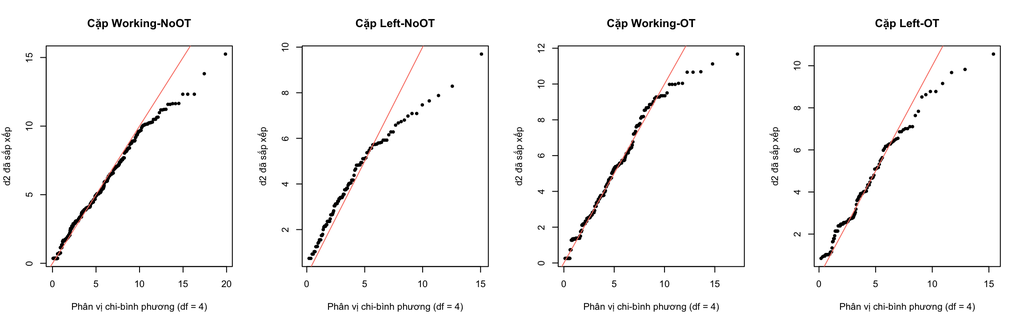

```r
par(mfrow = c(1, 4))
for (l in levels(o)) {
  d2 <- sort(d2_B[o == l]); m <- length(d2)
  plot(qchisq(((1:m) - 0.5) / m, df = 4), d2, pch = 19, cex = 0.6,
       main = paste("Cặp", l), xlab = "Phân vị chi-bình phương (df = 4)", ylab = "d2 đã sắp xếp")
  abline(0, 1, col = "salmon")
}
```

```r
par(mfrow = c(1, 1))
```

## 3.3 Tương quan và đa cộng tuyến giữa các biến phụ thuộc

Việc xét đồng thời các biến bằng MANOVA có ý nghĩa khi các biến phụ thuộc có tương quan với nhau; đồng thời các biến không được có đa cộng tuyến để ma trận phần dư $\mathbf W$ khả nghịch.

**Hệ số tương quan Pearson** giữa hai biến $i$ và $k$ trong một nhóm:

$$r_{ik} = \frac{s_{ik}}{\sqrt{s_{ii}}\sqrt{s_{kk}}} = \frac{\sum_j
(x_{ji} - \bar x_i)(x_{jk} - \bar x_k)}{\sqrt{\sum_j (x_{ji} - \bar
x_i)^2}\sqrt{\sum_j (x_{jk} - \bar x_k)^2}},$$

với $x_{ji}$ là giá trị biến $i$ của nhân viên $j$, $\bar x_i$ là trung bình biến $i$ trong nhóm, $s_{ik}$ là hiệp phương sai và $s_{ii}$, $s_{kk}$ là phương sai của hai biến. $r_{ik} \in [-1, 1]$ đo mức độ hai biến cùng tăng ($r > 0$) hoặc ngược chiều ($r < 0$) theo đường thẳng. Tương quan được tính **trong từng nhóm (cặp)**, vì nếu gộp các nhóm thì khác biệt trung bình giữa nhóm có thể tạo ra tương quan giả.

**Ma trận phần dư.** Với mô hình một nhân tố, $\mathbf W = (n_1 - 1)\mathbf S_1 + (n_2 - 1)\mathbf S_2$, trong đó $\mathbf S_1$, $\mathbf S_2$ là ma trận hiệp phương sai $9 \times 9$ của nhóm Working và Left: $\mathbf W$ cộng dồn biến thiên **trong nhóm** của 9 biến. Với mô hình hai nhân tố, $\mathbf E = \sum_{\ell,k,r} (\mathbf x_{\ell k r} - \bar{\mathbf x}_{\ell k})(\mathbf x_{\ell k r} - \bar{\mathbf x}_{\ell k})'$ cộng dồn biến thiên **trong cặp** của 4 biến, với $\bar{\mathbf x}_{\ell k}$ là trung bình của cặp (mức $\ell$ của Attrition, mức $k$ của OverTime). Các thống kê MANOVA dùng $\mathbf W^{-1}$ (hoặc $\mathbf E^{-1}$), nên các ma trận này phải khả nghịch.

**Kiểm tra đa cộng tuyến bằng VIF.** VIF được tính trên ma trận tương quan gộp trong nhóm $\mathbf R_{pooled}$, chuẩn hóa từ ma trận phần dư $\mathbf W = \sum_\ell (n_\ell - 1)\mathbf S_\ell$:

$$VIF_j = \left[\mathbf
R_{pooled}^{-1}\right]_{jj} = \frac{1}{1 - R_j^2},$$

với $R_j^2$ là hệ số xác định khi hồi quy biến j theo các biến còn lại (trong nhóm). Johnson & Wichern không đưa ra ngưỡng cho VIF; trong hồi quy, ngưỡng kinh nghiệm thường dùng là VIF vượt 5 hoặc 10 thì đa cộng tuyến đáng kể (James và cộng sự, *An Introduction to Statistical Learning*, 2013, mục 3.3.3). Bài này đọc VIF trực tiếp qua $R_j^2 = 1 - 1/VIF_j$ và dùng ngưỡng 5 để đối chiếu.

### 3.3.1 Một nhân tố – kịch bản 1 (giữ MonthlyIncome, 9 biến)

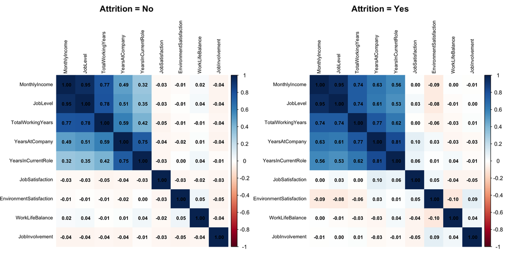

```r
par(mfrow = c(1, 2))
corrplot(cor(X1), method = "color", addCoef.col = "black", tl.col = "black",
         col.lim = c(-1, 1), number.cex = 0.7, tl.cex = 0.7,
         title = "Attrition = No", mar = c(0, 0, 2, 0))
corrplot(cor(X2), method = "color", addCoef.col = "black", tl.col = "black",
         col.lim = c(-1, 1), number.cex = 0.7, tl.cex = 0.7,
         title = "Attrition = Yes", mar = c(0, 0, 2, 0))
```

```r
par(mfrow = c(1, 1))
```

Trong mỗi nhóm, 5 biến thu nhập và kinh nghiệm tương quan dương với nhau (r từ 0.32 đến 0.95 ở nhóm Working, từ 0.53 đến 0.95 ở nhóm Left), mạnh nhất là `MonthlyIncome` – `JobLevel` (r ≈ 0.95). 4 biến tâm lý – hành vi gần như không tương quan với nhau và với các biến khác (|r| ≤ 0.05 ở nhóm Working, ≤ 0.10 ở nhóm Left).

```r
W_A <- (n1 - 1) * cov(X1) + (n2 - 1) * cov(X2)
R_pooled_A <- cov2cor(W_A)
vif_A <- diag(solve(R_pooled_A))
bang(data.frame(bien = bien, VIF = vif_A, R2 = 1 - 1 / vif_A), row.names = FALSE,
     col.names = c("Biến", "VIF", "R²_j = 1 − 1/VIF"), caption = paste0("det(R_pooled) = ", round(det(R_pooled_A), 4)))
```

det(R_pooled) = 0.01

| Biến | VIF | R²_j = 1 − 1/VIF |
| --- | --- | --- |
| MonthlyIncome | 10.346 | 0.903 |
| JobLevel | 10.758 | 0.907 |
| TotalWorkingYears | 3.066 | 0.674 |
| YearsAtCompany | 3.046 | 0.672 |
| YearsInCurrentRole | 2.336 | 0.572 |
| JobSatisfaction | 1.004 | 0.004 |
| EnvironmentSatisfaction | 1.002 | 0.002 |
| WorkLifeBalance | 1.008 | 0.008 |
| JobInvolvement | 1.005 | 0.005 |

`MonthlyIncome` (VIF = 10.35) và `JobLevel` (10.76) có $R_j^2 \approx 0.90$, tức mỗi biến được giải thích khoảng 90% bởi các biến còn lại, vượt ngưỡng kinh nghiệm 5 và 10: hai biến này có **đa cộng tuyến đáng kể** (mức lương gắn chặt với cấp bậc). 3 biến kinh nghiệm có VIF 2.34–3.07 ($R_j^2$ 0.57–0.67); 4 biến tâm lý – hành vi có VIF ≈ 1. $\det(\mathbf R_{pooled}) = 0.0100$ nhỏ nhưng khác 0, nên $\mathbf W$ vẫn khả nghịch và các thống kê MANOVA tính được.

### 3.3.2 Một nhân tố – kịch bản 2 (bỏ MonthlyIncome, 8 biến)

Vì `MonthlyIncome` và `JobLevel` gần như mang cùng một thông tin, kịch bản 2 bỏ `MonthlyIncome` và giữ `JobLevel`. `JobLevel` là thang thứ bậc 1–5, cùng dạng với các biến hài lòng – tham gia, nên chênh lệch giữa hai nhóm diễn giải trực tiếp theo số bậc; `MonthlyIncome` là biến liên tục lệch phải mạnh, có 114 ngoại lai một chiều (mục 2), nên chênh lệch phải diễn giải theo khoảng giá trị thu nhập.

```r
W_kb2 <- (n1 - 1) * cov(X1[, bien_kb2]) + (n2 - 1) * cov(X2[, bien_kb2])
R_pooled_kb2 <- cov2cor(W_kb2)
vif_kb2 <- diag(solve(R_pooled_kb2))
bang(data.frame(bien = bien_kb2, VIF = vif_kb2, R2 = 1 - 1 / vif_kb2), row.names = FALSE,
     col.names = c("Biến", "VIF", "R²_j = 1 − 1/VIF"),
     caption = paste0("Kịch bản 2 (8 biến), det(R_pooled) = ", round(det(R_pooled_kb2), 4)))
```

Kịch bản 2 (8 biến), det(R_pooled) = 0.1033

| Biến | VIF | R²_j = 1 − 1/VIF |
| --- | --- | --- |
| JobLevel | 2.540 | 0.606 |
| TotalWorkingYears | 2.993 | 0.666 |
| YearsAtCompany | 3.045 | 0.672 |
| YearsInCurrentRole | 2.330 | 0.571 |
| JobSatisfaction | 1.004 | 0.004 |
| EnvironmentSatisfaction | 1.002 | 0.002 |
| WorkLifeBalance | 1.008 | 0.008 |
| JobInvolvement | 1.005 | 0.005 |

Khi bỏ `MonthlyIncome`, VIF của `JobLevel` giảm từ 10.76 xuống 2.54 ($R_j^2$ = 0.61); VIF lớn nhất của kịch bản 2 là 3.05 (`YearsAtCompany`), đều dưới ngưỡng 5, và $\det(\mathbf R_{pooled})$ tăng từ 0.0100 lên 0.1033. Kịch bản 2 không còn đa cộng tuyến đáng kể.

### 3.3.3 Hai nhân tố (4 biến, theo 4 cặp)

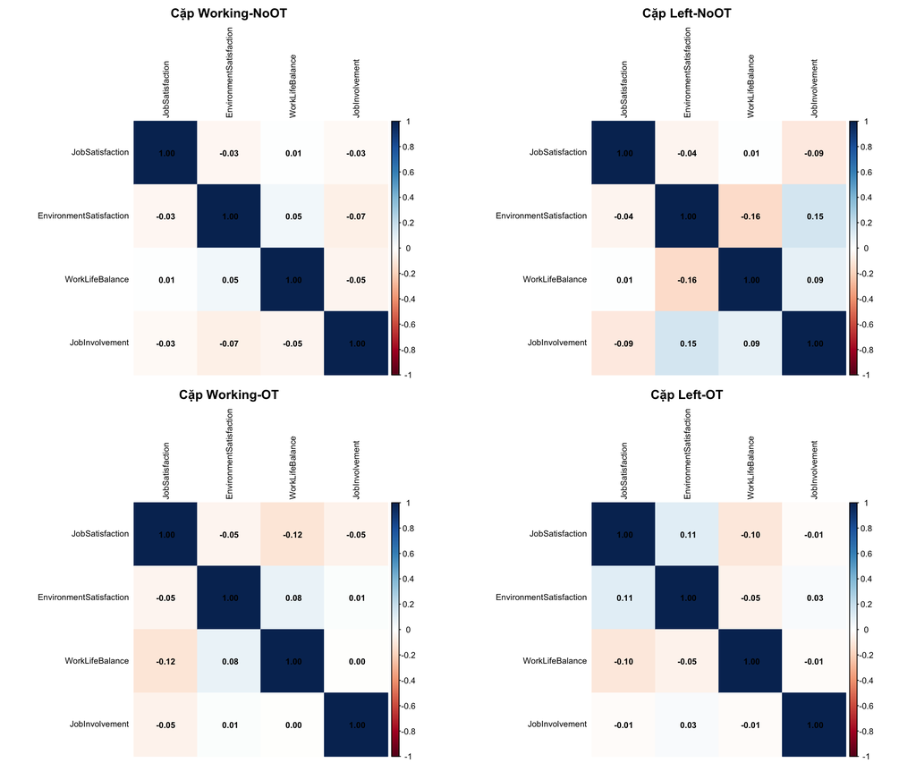

```r
par(mfrow = c(2, 2))
for (l in levels(o)) {
  corrplot(cor(Y[o == l, ]), method = "color", addCoef.col = "black", tl.col = "black",
           col.lim = c(-1, 1), number.cex = 0.8, tl.cex = 0.8,
           title = paste("Cặp", l), mar = c(0, 0, 2, 0))
}
```

```r
par(mfrow = c(1, 1))
```

Trong từng cặp, tương quan giữa 4 biến tâm lý – hành vi chỉ từ −0.16 đến 0.15.

```r
E_B <- crossprod(resid(lm(Y ~ Attrition * OverTime, data = ea)))
R_pooled_B <- cov2cor(E_B)
bang(R_pooled_B, caption = "Ma trận tương quan gộp trong cặp")
```

Ma trận tương quan gộp trong cặp

|  | JobSatisfaction | EnvironmentSatisfaction | WorkLifeBalance | JobInvolvement |
| --- | --- | --- | --- | --- |
| JobSatisfaction | 1.000 | -0.023 | -0.026 | -0.037 |
| EnvironmentSatisfaction | -0.023 | 1.000 | 0.022 | -0.025 |
| WorkLifeBalance | -0.026 | 0.022 | 1.000 | -0.023 |
| JobInvolvement | -0.037 | -0.025 | -0.023 | 1.000 |

Tương quan gộp trong cặp chỉ từ −0.037 đến 0.022: 4 biến gần như không tương quan.

```r
vif_B <- diag(solve(R_pooled_B))
bang(data.frame(bien = bien_tl, VIF = vif_B, R2 = 1 - 1 / vif_B), row.names = FALSE,
     col.names = c("Biến", "VIF", "R²_j = 1 − 1/VIF"), caption = paste0("det(R_pooled) = ", round(det(R_pooled_B), 4)))
```

det(R_pooled) = 0.9957

| Biến | VIF | R²_j = 1 − 1/VIF |
| --- | --- | --- |
| JobSatisfaction | 1.003 | 0.003 |
| EnvironmentSatisfaction | 1.002 | 0.002 |
| WorkLifeBalance | 1.002 | 0.002 |
| JobInvolvement | 1.003 | 0.003 |

VIF = 1.00 và $\det(\mathbf R_{pooled}) = 0.996$, nên không có đa cộng tuyến. Mặt khác, vì các biến gần như không tương quan, việc xét đồng thời 4 biến bằng MANOVA mang thêm ít thông tin so với phân tích riêng từng biến.

## 3.4 Chuẩn nhiều chiều (mshapiro_test)

Với mỗi nhóm (hoặc mỗi cặp), kiểm định giả thuyết

$$\begin{aligned}
H_0 &: \text{vectơ biến phụ thuộc có phân phối chuẩn nhiều chiều} \\
H_A &: \text{vectơ biến phụ thuộc không có phân phối chuẩn nhiều
chiều}
\end{aligned}$$

`rstatix::mshapiro_test()` đưa bài toán nhiều chiều về một chiều rồi dùng Shapiro-Wilk:

1. Trong mỗi nhóm (cặp), tính độ lệch $\mathbf r_j = \mathbf x_j - \bar{\mathbf x}$ của từng nhân viên và ma trận tổng tích chéo $\mathbf A = \sum_j \mathbf r_j \mathbf r_j' = (n - 1)\mathbf S$.
2. Tìm nhân viên xa tâm nhất theo khoảng cách $\mathbf r_j' \mathbf A^{-1} \mathbf r_j$ (tỷ lệ với $d_j^2$ ở mục ngoại lai); gọi độ lệch của nhân viên này là $\mathbf r_{max}$.
3. Chiếu mọi quan sát lên hướng $\mathbf c = \mathbf A^{-1}\mathbf r_{max}$: $z_j = \mathbf c' \mathbf x_j$, được một biến một chiều $z$.
4. Tính thống kê $W$ của Shapiro-Wilk cho $z_1, \dots, z_n$ (công thức ở mục chuẩn từng biến dưới đây).

Nếu vectơ $\mathbf x$ chuẩn nhiều chiều thì mọi tổ hợp tuyến tính $\mathbf c'\mathbf x$ đều chuẩn (Johnson & Wichern, Kết quả 4.2), nên $z$ phải chuẩn. Hướng $\mathbf c$ được chọn theo quan sát xa tâm nhất, là hướng mà độ lệch khỏi phân phối chuẩn dễ thể hiện nhất; $W$ nhỏ trên hướng này là bằng chứng chống lại chuẩn nhiều chiều.

```r
bang_mshapiro <- function(M, f) {
  kq <- data.frame(nhom = levels(f), statistic = NA, p_value = NA)
  for (k in seq_along(levels(f))) {
    ms <- mshapiro_test(as.data.frame(M[f == levels(f)[k], ]))
    kq$statistic[k] <- round(ms$statistic, 4)
    kq$p_value[k]   <- ms$p.value
  }
  kq
}
```

### 3.4.1 Một nhân tố – kịch bản 1 (giữ MonthlyIncome, 9 biến)

```r
bang_mshapiro_A <- bang_mshapiro(X, nhom_nhan)
bang(transform(bang_mshapiro_A, p_value = fp(p_value)), row.names = FALSE,
     col.names = c("Nhóm", "Thống kê W", "p-giá trị"))
```

| Nhóm | Thống kê W | p-giá trị |
| --- | --- | --- |
| Working | 0.901 | 1.61e-27 |
| Left | 0.674 | 3.98e-21 |

Nhóm Working (p-giá trị = 1.61e-27) và nhóm Left (p-giá trị = 3.98e-21) có p-giá trị < 0.05 nên ta bác bỏ $H_0$ với mức ý nghĩa 5%, nghĩa là vectơ 9 biến không có phân phối chuẩn nhiều chiều; p-giá trị rất nhỏ nên đây là **vi phạm nặng**.

### 3.4.2 Một nhân tố – kịch bản 2 (bỏ MonthlyIncome, 8 biến)

```r
bang_mshapiro_kb2 <- bang_mshapiro(X_kb2, nhom_nhan)
bang(transform(bang_mshapiro_kb2, p_value = fp(p_value)), row.names = FALSE,
     col.names = c("Nhóm", "Thống kê W", "p-giá trị"))
```

| Nhóm | Thống kê W | p-giá trị |
| --- | --- | --- |
| Working | 0.893 | 2.22e-28 |
| Left | 0.674 | 4.08e-21 |

### 3.4.3 Hai nhân tố (4 biến, theo 4 cặp)

```r
bang_mshapiro_B <- bang_mshapiro(Y, o)
bang(transform(bang_mshapiro_B, p_value = fp(p_value)), row.names = FALSE,
     col.names = c("Cặp", "Thống kê W", "p-giá trị"))
```

| Cặp | Thống kê W | p-giá trị |
| --- | --- | --- |
| Working-NoOT | 0.993 | 0.000217 |
| Left-NoOT | 0.990 | 0.566 |
| Working-OT | 0.988 | 0.0134 |
| Left-OT | 0.968 | 0.00377 |

Cặp `Left-NoOT` có p-giá trị = 0.566 > 0.05 nên ta không bác bỏ $H_0$, nghĩa là chưa có cơ sở cho rằng vectơ 4 biến trong cặp này không chuẩn. Ba cặp `Working-NoOT` (p-giá trị = 0.000217), `Working-OT` (0.0134) và `Left-OT` (0.00377) có p-giá trị < 0.05 nên ta bác bỏ $H_0$ với mức ý nghĩa 5%; đây là vi phạm nhẹ.

## 3.5 Chuẩn từng biến (Shapiro-Wilk)

Với mỗi biến trong mỗi nhóm (hoặc mỗi cặp), kiểm định giả thuyết

$$\begin{aligned}
H_0 &: \text{biến có phân phối chuẩn} \\
H_A &: \text{biến không có phân phối chuẩn}
\end{aligned}$$

Thống kê Shapiro-Wilk cho một biến trong một nhóm (cặp) có $n$ quan sát:

$$W = \frac{\left(\sum_{i=1}^{n} a_i\, x_{(i)}\right)^2}{\sum_{i=1}^{n}
(x_i - \bar x)^2},$$

trong đó:

- $x_1, \dots, x_n$: giá trị của biến (ví dụ `WorkLifeBalance`) của các nhân viên trong nhóm; $\bar x$ là trung bình của chúng.
- $x_{(1)} \le x_{(2)} \le \dots \le x_{(n)}$: các giá trị đó sau khi sắp xếp tăng dần (thống kê thứ tự).
- $a_i$: hệ số cố định, tính từ trung bình và hiệp phương sai của các thống kê thứ tự của một mẫu cỡ $n$ lấy từ phân phối chuẩn tắc; chỉ phụ thuộc $n$, không phụ thuộc dữ liệu.
- Mẫu số $\sum (x_i - \bar x)^2 = (n-1)s^2$: tổng bình phương độ lệch, tỷ lệ với phương sai mẫu.

Tử số là bình phương của một ước lượng độ lệch chuẩn **nếu dữ liệu chuẩn**, mẫu số là ước lượng thông thường; nên $0 < W \le 1$, $W$ gần 1 khi các giá trị sắp xếp khớp với dạng phân phối chuẩn, và $W$ nhỏ (p-giá trị nhỏ) khi phân phối lệch, nhiều giá trị trùng nhau hoặc có đuôi nặng.

### 3.5.1 Một nhân tố (9 biến × 2 nhóm)

```r
bang_shapiro_A <- sapply(levels(nhom), function(l)
  apply(X[nhom == l, ], 2, function(x) shapiro.test(x)$p.value))
colnames(bang_shapiro_A) <- nhan_attrition[colnames(bang_shapiro_A)]
bang(apply(bang_shapiro_A, 2, fp), caption = "p-giá trị Shapiro-Wilk")
```

p-giá trị Shapiro-Wilk

|  | Working | Left |
| --- | --- | --- |
| MonthlyIncome | 5.97e-34 | 1.5e-17 |
| JobLevel | 6.63e-34 | 2.72e-20 |
| TotalWorkingYears | 2.1e-26 | 2.07e-14 |
| YearsAtCompany | 1.67e-32 | 1.3e-19 |
| YearsInCurrentRole | 8.44e-27 | 6.26e-16 |
| JobSatisfaction | 2.88e-33 | 2.31e-14 |
| EnvironmentSatisfaction | 1.05e-32 | 4.69e-15 |
| WorkLifeBalance | 5.99e-37 | 4.84e-15 |
| JobInvolvement | 3.59e-36 | 7.93e-16 |

Cả 18 trường hợp có p-giá trị < 0.05 (lớn nhất 2.31e-14) nên ta bác bỏ $H_0$ với mức ý nghĩa 5%, nghĩa là không biến nào có phân phối chuẩn trong nhóm; p-giá trị rất nhỏ nên đây là **vi phạm nặng**.

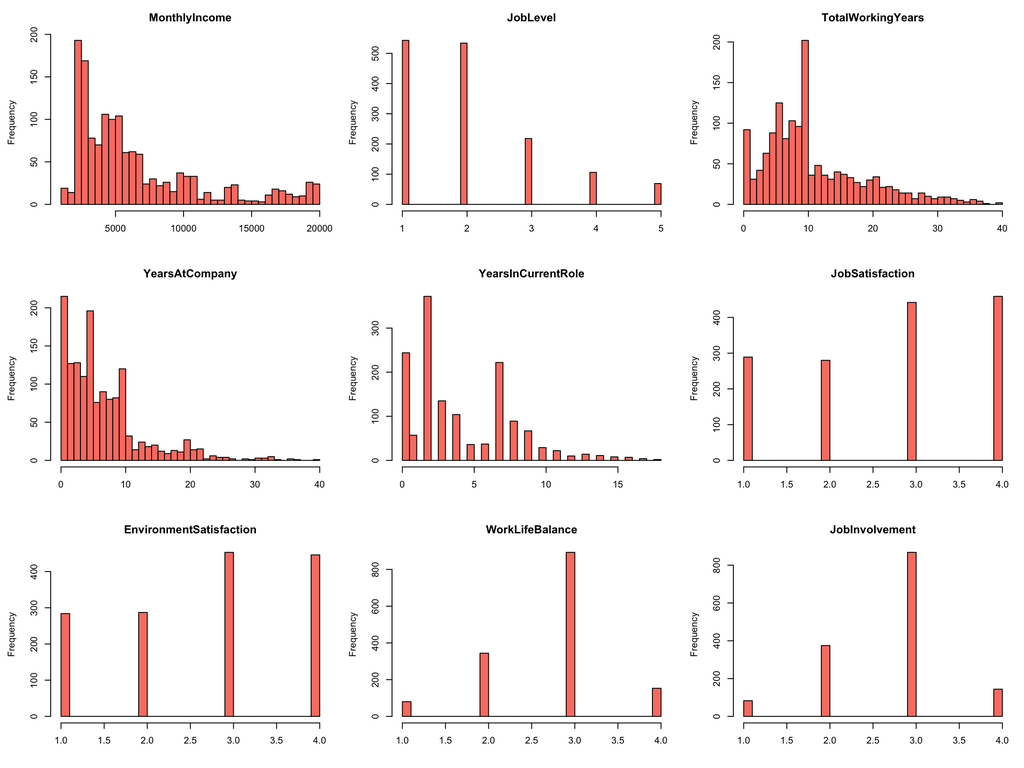

```r
par(mfrow = c(3, 3), mar = c(4, 4.5, 3, 1))
for (v in bien) hist(ea[[v]], breaks = 30, main = v, xlab = "", col = "salmon")
```

```r
par(mfrow = c(1, 1))
```

Histogram cho thấy nguyên nhân: 5 biến thứ bậc chỉ nhận 4–5 giá trị rời rạc, còn thu nhập và các biến số năm lệch phải.

Shapiro-Wilk xét từng biến riêng, nên kịch bản 2 có cùng kết quả với 8 biến còn lại trong bảng trên.

### 3.5.2 Hai nhân tố (4 biến × 4 cặp)

```r
bang_shapiro_B <- sapply(levels(o), function(l)
  apply(Y[o == l, ], 2, function(x) shapiro.test(x)$p.value))
bang(apply(bang_shapiro_B, 2, fp), caption = "p-giá trị Shapiro-Wilk")
```

p-giá trị Shapiro-Wilk

|  | Working-NoOT | Left-NoOT | Working-OT | Left-OT |
| --- | --- | --- | --- | --- |
| JobSatisfaction | 4.92e-29 | 1.52e-09 | 7.77e-18 | 1.03e-09 |
| EnvironmentSatisfaction | 6.13e-29 | 4.12e-10 | 1.16e-16 | 2.14e-10 |
| WorkLifeBalance | 7.59e-33 | 4.86e-09 | 2.61e-19 | 2.77e-11 |
| JobInvolvement | 2.92e-32 | 5.46e-10 | 2e-18 | 2.26e-11 |

Cả 16 trường hợp có p-giá trị < 0.05 (lớn nhất 4.86e-09) nên ta bác bỏ $H_0$ với mức ý nghĩa 5%, nghĩa là không biến tâm lý – hành vi nào có phân phối chuẩn trong cặp; p-giá trị rất nhỏ nên đây là **vi phạm nặng**, do các biến chỉ nhận 4 giá trị 1–4.

## 3.6 Đồng nhất ma trận hiệp phương sai (Box’s M)

Thống kê Box’s M (Johnson & Wichern, mục 6.6, công thức 6-48 đến 6-52) so sánh ma trận hiệp phương sai của $g$ nhóm (cặp):

$$\mathbf S_{pooled} = \frac{\sum_{\ell=1}^{g}(n_\ell - 1)\mathbf
S_\ell}{\sum_{\ell=1}^{g}(n_\ell - 1)}, \qquad
M = \Big[\sum_{\ell}(n_\ell - 1)\Big]\ln|\mathbf S_{pooled}| -
\sum_{\ell}(n_\ell - 1)\ln|\mathbf S_\ell|,$$

$$u = \left[\sum_{\ell}\frac{1}{n_\ell - 1} - \frac{1}{\sum_{\ell}(n_\ell
- 1)}\right]\frac{2p^2 + 3p - 1}{6(p+1)(g-1)}, \qquad C = (1 - u)M,$$

trong đó:

- $g$: số nhóm (2 nhóm Working/Left, hoặc 4 cặp); $n_\ell$: số nhân viên của nhóm (cặp) $\ell$; $p$: số biến phụ thuộc (9 hoặc 4).
- $\mathbf S_\ell$: ma trận hiệp phương sai mẫu $p \times p$ của nhóm (cặp) $\ell$ (đường chéo là phương sai từng biến, ngoài đường chéo là hiệp phương sai từng cặp biến).
- $\mathbf S_{pooled}$: ma trận hiệp phương sai gộp, là trung bình có trọng số của các $\mathbf S_\ell$ — ước lượng của $\boldsymbol\Sigma$ chung nếu $H_0$ đúng.
- $|\mathbf S|$: định thức của ma trận hiệp phương sai, gọi là **phương sai tổng quát**, đo độ phân tán tổng thể của $p$ biến cùng lúc.
- $M$: so sánh phương sai tổng quát của ma trận gộp với của từng nhóm. Nếu các $\mathbf S_\ell$ gần nhau thì $|\mathbf S_\ell| \approx |\mathbf S_{pooled}|$ và $M$ gần 0; các $\mathbf S_\ell$ càng khác nhau thì $M$ càng lớn.
- $u$: hệ số hiệu chỉnh của Box để $C$ xấp xỉ tốt phân phối $\chi^2$.

Khi $H_0$ đúng, $C$ có phân phối xấp xỉ $\chi^2_\nu$ với $\nu = \frac12 p(p+1)(g-1)$ bậc tự do (bằng số phần tử khác nhau của một ma trận $p \times p$ đối xứng, nhân với $g - 1$); bác bỏ $H_0$ khi $C > \chi^2_\nu(1-\alpha)$. Theo Johnson & Wichern, xấp xỉ này tốt khi mỗi $n_\ell > 20$ và $p, g \le 5$.

### 3.6.1 Một nhân tố – kịch bản 1 (giữ MonthlyIncome, 9 biến)

Kiểm định giả thuyết

$$\begin{aligned}
H_0 &: \boldsymbol\Sigma_1 = \boldsymbol\Sigma_2 = \boldsymbol\Sigma
\\
H_A &: \boldsymbol\Sigma_1 \neq \boldsymbol\Sigma_2
\end{aligned}$$

với p = 9, g = 2 nên $\nu = 45$. Vì p = 9 > 5 nên xấp xỉ $\chi^2$ kém chính xác hơn.

```r
box_m_A <- box_m(as.data.frame(X), nhom)
bang(data.frame(C = box_m_A$statistic, df = box_m_A$parameter, phan_vi = qchisq(0.95, df = 45),
                p = fp(box_m_A$p.value), muc_do = muc_do(box_m_A$p.value)), digits = 2, row.names = FALSE,
     col.names = c("Thống kê C", "Bậc tự do", "χ²45(0.95)", "p-giá trị", "Mức độ"))
```

| Thống kê C | Bậc tự do | χ²45(0.95) | p-giá trị | Mức độ |
| --- | --- | --- | --- | --- |
| 174.12 | 45 | 61.66 | 4.37e-17 | Vi phạm nặng |

### 3.6.2 Một nhân tố – kịch bản 2 (bỏ MonthlyIncome, 8 biến)

Cùng cặp giả thuyết như kịch bản 1, với p = 8, g = 2 nên $\nu = 36$. Vì p = 8 > 5 nên xấp xỉ $\chi^2$ kém chính xác hơn.

```r
box_m_kb2 <- box_m(as.data.frame(X_kb2), nhom)
bang(data.frame(C = box_m_kb2$statistic, df = box_m_kb2$parameter, phan_vi = qchisq(0.95, df = 36),
                p = fp(box_m_kb2$p.value), muc_do = muc_do(box_m_kb2$p.value)), digits = 2, row.names = FALSE,
     col.names = c("Thống kê C", "Bậc tự do", "χ²36(0.95)", "p-giá trị", "Mức độ"))
```

| Thống kê C | Bậc tự do | χ²36(0.95) | p-giá trị | Mức độ |
| --- | --- | --- | --- | --- |
| 125.27 | 36 | 51 | 8.46e-12 | Vi phạm nặng |

### 3.6.3 Hai nhân tố (4 biến, 4 cặp)

Kiểm định giả thuyết

$$\begin{aligned}
H_0 &: \boldsymbol\Sigma_{11} = \boldsymbol\Sigma_{12} =
\boldsymbol\Sigma_{21} = \boldsymbol\Sigma_{22} = \boldsymbol\Sigma \\
H_A &: \text{có ít nhất hai cặp có ma trận hiệp phương sai khác
nhau}
\end{aligned}$$

với p = 4 và 4 cặp nên $\nu = 30$. Các điều kiện xấp xỉ đều thỏa (cặp nhỏ nhất có 110 quan sát, p = 4, 4 cặp).

```r
box_m_B <- box_m(as.data.frame(Y), o)
bang(data.frame(C = box_m_B$statistic, df = box_m_B$parameter, phan_vi = qchisq(0.95, df = 30),
                p = fp(box_m_B$p.value), muc_do = muc_do(box_m_B$p.value)), digits = 2, row.names = FALSE,
     col.names = c("Thống kê C", "Bậc tự do", "χ²30(0.95)", "p-giá trị", "Mức độ"))
```

| Thống kê C | Bậc tự do | χ²30(0.95) | p-giá trị | Mức độ |
| --- | --- | --- | --- | --- |
| 54.75 | 30 | 43.77 | 0.00379 | Vi phạm nhẹ |

$C = 54.7 > 43.77 = \chi^2_{30}(0.95)$, p-giá trị = 0.00379 < 0.05, nên ta bác bỏ $H_0$ với mức ý nghĩa 5%, nghĩa là ma trận hiệp phương sai của 4 cặp không bằng nhau; đây là vi phạm nhẹ.

## 3.7 Đồng nhất phương sai từng biến (Levene)

Với mỗi biến, kiểm định giả thuyết

$$\begin{aligned}
H_0 &: \text{phương sai của biến bằng nhau giữa các nhóm (các cặp)}
\\
H_A &: \text{có ít nhất hai nhóm (cặp) có phương sai khác nhau}
\end{aligned}$$

`rstatix::levene_test()` dùng phiên bản lấy trung vị làm tâm (mặc định `center = median`, còn gọi là kiểm định Brown–Forsythe). Với một biến và $k$ nhóm (cặp):

$$z_{ij} = |x_{ij} - \tilde x_i|, \qquad
F = \frac{N - k}{k - 1}\cdot\frac{\sum_{i=1}^{k} n_i(\bar z_i - \bar
z)^2}{\sum_{i=1}^{k}\sum_{j=1}^{n_i}(z_{ij} - \bar z_i)^2},$$

trong đó:

- $x_{ij}$: giá trị của biến ở nhân viên $j$ trong nhóm $i$; $\tilde x_i$: trung vị của biến trong nhóm $i$.
- $z_{ij}$: độ lệch tuyệt đối của nhân viên đó so với trung vị nhóm, đo mức “phân tán” của từng quan sát.
- $\bar z_i$: trung bình độ lệch tuyệt đối trong nhóm $i$ (nhóm có phương sai lớn thì $\bar z_i$ lớn); $\bar z$: trung bình chung của mọi $z_{ij}$.
- $n_i$: số nhân viên trong nhóm $i$; $N = \sum n_i$; $k = 2$ (Working/Left) hoặc $k = 4$ (4 cặp).

$F$ thực chất là thống kê ANOVA một nhân tố áp dụng cho $z_{ij}$: tử số đo khác biệt về mức phân tán trung bình giữa các nhóm, mẫu số đo biến thiên của $z$ trong nhóm. Khi $H_0$ đúng, $F \sim F_{k-1,\,N-k}$; $F$ lớn (p-giá trị nhỏ) nghĩa là phương sai của biến khác nhau giữa các nhóm. Dùng trung vị thay trung bình giúp kiểm định ít nhạy với dữ liệu không chuẩn.

```r
ea_dai <- pivot_longer(ea, cols = all_of(bien), names_to = "bien", values_to = "gia_tri")
```

### 3.7.1 Một nhân tố (9 biến, theo Attrition)

```r
bang_levene_A <- levene_test(group_by(ea_dai, bien), gia_tri ~ Attrition)
bang_levene_A <- bang_levene_A[match(bien, bang_levene_A$bien), ]
bang(data.frame(bang_levene_A[, c("bien", "df1", "df2", "statistic")], p = fp(bang_levene_A$p),
                muc_do = muc_do(bang_levene_A$p)), digits = 2, row.names = FALSE,
     col.names = c("Biến", "df1", "df2", "Thống kê F", "p-giá trị", "Mức độ"))
```

| Biến | df1 | df2 | Thống kê F | p-giá trị | Mức độ |
| --- | --- | --- | --- | --- | --- |
| MonthlyIncome | 1 | 1468 | 14.90 | 0.000118 | Vi phạm nhẹ |
| JobLevel | 1 | 1468 | 7.29 | 0.00703 | Vi phạm nhẹ |
| TotalWorkingYears | 1 | 1468 | 3.06 | 0.0803 | Thỏa |
| YearsAtCompany | 1 | 1468 | 2.75 | 0.0973 | Thỏa |
| YearsInCurrentRole | 1 | 1468 | 16.02 | 6.57e-05 | Vi phạm nặng |
| JobSatisfaction | 1 | 1468 | 3.23 | 0.0725 | Thỏa |
| EnvironmentSatisfaction | 1 | 1468 | 14.42 | 0.000152 | Vi phạm nhẹ |
| WorkLifeBalance | 1 | 1468 | 12.03 | 0.00054 | Vi phạm nhẹ |
| JobInvolvement | 1 | 1468 | 12.24 | 0.000483 | Vi phạm nhẹ |

`TotalWorkingYears` (p = 0.0803), `YearsAtCompany` (p = 0.0973) và `JobSatisfaction` (p = 0.0725) có p-giá trị > 0.05 nên ta không bác bỏ $H_0$, nghĩa là chưa có cơ sở cho rằng phương sai của các biến này khác nhau giữa hai nhóm. `MonthlyIncome` (p = 0.000118), `JobLevel` (0.00703), `EnvironmentSatisfaction` (0.000152), `WorkLifeBalance` (0.00054) và `JobInvolvement` (0.000483) có p-giá trị < 0.05 nên ta bác bỏ $H_0$ với mức ý nghĩa 5%; đây là vi phạm nhẹ. `YearsInCurrentRole` (p = 6.57e-05) bác bỏ $H_0$; p-giá trị rất nhỏ nên đây là vi phạm nặng.

Levene xét từng biến riêng, nên kịch bản 2 có cùng kết quả với 8 biến còn lại trong bảng trên.

### 3.7.2 Hai nhân tố (4 biến, theo 4 cặp)

```r
bang_levene_B <- levene_test(group_by(filter(ea_dai, bien %in% bien_tl), bien), gia_tri ~ Attrition * OverTime)
bang_levene_B <- bang_levene_B[match(bien_tl, bang_levene_B$bien), ]
bang(data.frame(bang_levene_B[, c("bien", "df1", "df2", "statistic")], p = fp(bang_levene_B$p),
                muc_do = muc_do(bang_levene_B$p)), digits = 2, row.names = FALSE,
     col.names = c("Biến", "df1", "df2", "Thống kê F", "p-giá trị", "Mức độ"))
```

| Biến | df1 | df2 | Thống kê F | p-giá trị | Mức độ |
| --- | --- | --- | --- | --- | --- |
| JobSatisfaction | 3 | 1466 | 1.59 | 0.189 | Thỏa |
| EnvironmentSatisfaction | 3 | 1466 | 7.86 | 3.35e-05 | Vi phạm nặng |
| WorkLifeBalance | 3 | 1466 | 5.15 | 0.00152 | Vi phạm nhẹ |
| JobInvolvement | 3 | 1466 | 4.36 | 0.00457 | Vi phạm nhẹ |

`JobSatisfaction` (p = 0.189) không bác bỏ $H_0$. `WorkLifeBalance` (p = 0.00152) và `JobInvolvement` (p = 0.00457) bác bỏ $H_0$ với mức ý nghĩa 5%, vi phạm nhẹ. `EnvironmentSatisfaction` (p = 3.35e-05) bác bỏ $H_0$, vi phạm nặng.

## 3.8 Tổng hợp mức độ vi phạm và hướng xử lý

```r
lv_kb2 <- bang_levene_A[bang_levene_A$bien %in% bien_kb2, ]   # Levene của 8 biến (kịch bản 2)
bang_vi_pham <- data.frame(
  mo_hinh = c(rep("Một nhân tố (9 biến)", 5), rep("Một nhân tố (8 biến)", 5), rep("Hai nhân tố (4 biến)", 7)),
  loai_gia_dinh = c(rep(c("p chiều", "p chiều", "p chiều", "Từng biến", "Từng biến"), 2),
                    rep("p chiều", 5), "Từng biến", "Từng biến"),
  gia_dinh = c(paste("Chuẩn nhiều chiều -", bang_mshapiro_A$nhom),
               "Đồng nhất ma trận hiệp phương sai (Box's M)",
               "Chuẩn từng biến (Shapiro-Wilk, p nhỏ nhất)",
               "Đồng nhất phương sai từng biến (Levene, p nhỏ nhất)",
               paste("Chuẩn nhiều chiều -", bang_mshapiro_kb2$nhom),
               "Đồng nhất ma trận hiệp phương sai (Box's M)",
               "Chuẩn từng biến (Shapiro-Wilk, p nhỏ nhất)",
               "Đồng nhất phương sai từng biến (Levene, p nhỏ nhất)",
               paste("Chuẩn nhiều chiều -", bang_mshapiro_B$nhom),
               "Đồng nhất ma trận hiệp phương sai (Box's M)",
               "Chuẩn từng biến (Shapiro-Wilk, p nhỏ nhất)",
               "Đồng nhất phương sai từng biến (Levene, p nhỏ nhất)"),
  p_value = c(bang_mshapiro_A$p_value, box_m_A$p.value,
              min(bang_shapiro_A), min(bang_levene_A$p),
              bang_mshapiro_kb2$p_value, box_m_kb2$p.value,
              min(bang_shapiro_A[bien_kb2, ]), min(lv_kb2$p),
              bang_mshapiro_B$p_value, box_m_B$p.value,
              min(bang_shapiro_B), min(bang_levene_B$p))
)
bang_vi_pham$muc_do  <- muc_do(bang_vi_pham$p_value)
bang_vi_pham$p_value <- fp(bang_vi_pham$p_value)
```

### 3.8.1 Một nhân tố – kịch bản 1 (giữ MonthlyIncome, 9 biến)

```r
bang(bang_vi_pham[bang_vi_pham$mo_hinh == "Một nhân tố (9 biến)", -1], row.names = FALSE,
     col.names = c("Loại giả định", "Giả định", "p-giá trị", "Mức độ"))
```

| Loại giả định | Giả định | p-giá trị | Mức độ |
| --- | --- | --- | --- |
| p chiều | Chuẩn nhiều chiều - Working | 1.61e-27 | Vi phạm nặng |
| p chiều | Chuẩn nhiều chiều - Left | 3.98e-21 | Vi phạm nặng |
| p chiều | Đồng nhất ma trận hiệp phương sai (Box’s M) | 4.37e-17 | Vi phạm nặng |
| Từng biến | Chuẩn từng biến (Shapiro-Wilk, p nhỏ nhất) | 5.99e-37 | Vi phạm nặng |
| Từng biến | Đồng nhất phương sai từng biến (Levene, p nhỏ nhất) | 6.57e-05 | Vi phạm nặng |

Cả giả định p chiều (chuẩn nhiều chiều ở hai nhóm, Box’s M) và giả định từng biến (chuẩn, Levene) đều **vi phạm nặng**; cỡ mẫu hai nhóm không cân bằng (1233 và 237); có đa cộng tuyến giữa `MonthlyIncome` và `JobLevel`.

### 3.8.2 Một nhân tố – kịch bản 2 (bỏ MonthlyIncome, 8 biến)

```r
bang(bang_vi_pham[bang_vi_pham$mo_hinh == "Một nhân tố (8 biến)", -1], row.names = FALSE,
     col.names = c("Loại giả định", "Giả định", "p-giá trị", "Mức độ"))
```

| Loại giả định | Giả định | p-giá trị | Mức độ |
| --- | --- | --- | --- |
| p chiều | Chuẩn nhiều chiều - Working | 2.22e-28 | Vi phạm nặng |
| p chiều | Chuẩn nhiều chiều - Left | 4.08e-21 | Vi phạm nặng |
| p chiều | Đồng nhất ma trận hiệp phương sai (Box’s M) | 8.46e-12 | Vi phạm nặng |
| Từng biến | Chuẩn từng biến (Shapiro-Wilk, p nhỏ nhất) | 5.99e-37 | Vi phạm nặng |
| Từng biến | Đồng nhất phương sai từng biến (Levene, p nhỏ nhất) | 6.57e-05 | Vi phạm nặng |

Bỏ `MonthlyIncome` loại được đa cộng tuyến (VIF lớn nhất 3.05) nhưng không thay đổi mức độ vi phạm: chuẩn nhiều chiều, Box’s M, chuẩn từng biến và Levene vẫn **vi phạm nặng**. Vì vậy hai kịch bản dùng cùng hướng xử lý dưới đây, và MANOVA ở mục 4 được chạy cho cả hai kịch bản để so sánh kết luận.

### 3.8.3 Hai nhân tố (4 biến)

```r
bang(bang_vi_pham[bang_vi_pham$mo_hinh == "Hai nhân tố (4 biến)", -1], row.names = FALSE,
     col.names = c("Loại giả định", "Giả định", "p-giá trị", "Mức độ"))
```

| Loại giả định | Giả định | p-giá trị | Mức độ |
| --- | --- | --- | --- |
| p chiều | Chuẩn nhiều chiều - Working-NoOT | 0.000217 | Vi phạm nhẹ |
| p chiều | Chuẩn nhiều chiều - Left-NoOT | 0.566 | Thỏa |
| p chiều | Chuẩn nhiều chiều - Working-OT | 0.0134 | Vi phạm nhẹ |
| p chiều | Chuẩn nhiều chiều - Left-OT | 0.00377 | Vi phạm nhẹ |
| p chiều | Đồng nhất ma trận hiệp phương sai (Box’s M) | 0.00379 | Vi phạm nhẹ |
| Từng biến | Chuẩn từng biến (Shapiro-Wilk, p nhỏ nhất) | 7.59e-33 | Vi phạm nặng |
| Từng biến | Đồng nhất phương sai từng biến (Levene, p nhỏ nhất) | 3.35e-05 | Vi phạm nặng |

Giả định p chiều chỉ vi phạm nhẹ (chuẩn nhiều chiều ở 3/4 cặp, Box’s M), nhưng giả định từng biến vi phạm nặng (chuẩn ở mọi biến, Levene ở `EnvironmentSatisfaction`); cỡ mẫu 4 cặp không cân bằng (từ 110 đến 944).

### 3.8.4 Hướng xử lý

Theo quy trình 4 bước của môn học: MANOVA luôn được thực hiện và dùng làm baseline; khi giả định từng biến cũng vi phạm nặng (bước 4) thì thử biến đổi dữ liệu, nếu không được thì dùng phương pháp phi tham số / vững, và MANOVA cổ điển chỉ để tham khảo. Với dữ liệu này, biến đổi (ví dụ log) không làm 5 biến thứ bậc 4–5 mức có phân phối chuẩn, nên mục 4 dùng:

1. MANOVA cổ điển (Wilks, Pillai) theo yêu cầu của đề, làm baseline. Theo Johnson & Wichern (mục 6.6), với cỡ mẫu lớn như ở đây (n = 1470) các kiểm định MANOVA về trung bình khá vững với dữ liệu không chuẩn; theo mục 6.7, Pillai có phần vững hơn các thống kê khác.
2. Kiểm định không cần giả định chuẩn: hoán vị Pillai, PERMANOVA (kèm betadisper), MANOVA trên hạng.
3. Bootstrap trong từng nhóm cho vi phạm Box’s M, vì hai nhóm có cỡ mẫu chênh lệch lớn nên khác biệt hiệp phương sai có thể ảnh hưởng đến MANOVA.
4. So sánh kết luận của kịch bản 1 (9 biến) và kịch bản 2 (bỏ `MonthlyIncome`, 8 biến) để kiểm tra ảnh hưởng của đa cộng tuyến.

# 4 Kiểm định MANOVA một nhân tố

Ký hiệu nhóm $\ell = 1$ là **Working** (đang làm việc, $n_1 = 1233$) và $\ell = 2$ là **Left** (đã nghỉ việc, $n_2 = 237$); tổng $n = n_1 + n_2 = 1470$, số biến phụ thuộc $p = 9$, số nhóm $g = 2$. $\boldsymbol\mu_\ell$ là vectơ trung bình tổng thể $9 \times 1$ của 9 biến ở nhóm $\ell$, $\boldsymbol\mu$ là vectơ trung bình chung và $\boldsymbol\tau_\ell = \boldsymbol\mu_\ell - \boldsymbol\mu$ là tác động của nhóm $\ell$ (độ lệch của trung bình nhóm so với trung bình chung).

Kiểm định giả thuyết

$$\begin{aligned}
H_0 &: \boldsymbol\tau_1 = \boldsymbol\tau_2 = \mathbf 0 \quad
(\boldsymbol\mu_1 = \boldsymbol\mu_2) \\
H_A &: \text{tồn tại } \boldsymbol\tau_\ell \neq \mathbf 0 \quad
(\boldsymbol\mu_1 \neq \boldsymbol\mu_2)
\end{aligned}$$

Các mục từ Wilks đến kiểm tra tính vững được tính cho **kịch bản 1** (9 biến, đúng vectơ biến của đề); **kịch bản 2** (bỏ `MonthlyIncome`, 8 biến, xem mục 3) được chạy lại toàn bộ ở mục cuối.

## 4.1 Thống kê Wilks lambda

### 4.1.1 Phân tách biến thiên: ma trận B và W

Giống ANOVA một chiều tách tổng bình phương thành phần “giữa nhóm” và “trong nhóm”, MANOVA tách ma trận tổng bình phương và tích chéo (SSP) của 9 biến (Johnson & Wichern, mục 6.4):

$$\underbrace{\sum_{\ell=1}^{g}\sum_{j=1}^{n_\ell}(\mathbf x_{\ell j} -
\bar{\mathbf x})(\mathbf x_{\ell j} - \bar{\mathbf
x})'}_{\text{tổng}}
= \underbrace{\sum_{\ell=1}^{g} n_\ell(\bar{\mathbf x}_\ell -
\bar{\mathbf x})(\bar{\mathbf x}_\ell - \bar{\mathbf x})'}_{\mathbf
B\ \text{(giữa nhóm)}}
+ \underbrace{\sum_{\ell=1}^{g}\sum_{j=1}^{n_\ell}(\mathbf x_{\ell j} -
\bar{\mathbf x}_\ell)(\mathbf x_{\ell j} - \bar{\mathbf
x}_\ell)'}_{\mathbf W\ \text{(trong nhóm)}},$$

trong đó:

- $\mathbf x_{\ell j}$: vectơ $9 \times 1$ giá trị 9 biến của nhân viên thứ $j$ trong nhóm $\ell$.
- $\bar{\mathbf x}_\ell$: vectơ trung bình mẫu của nhóm $\ell$ (trung bình từng biến trong nhóm Working hoặc Left); $\bar{\mathbf x}$: vectơ trung bình của toàn bộ 1470 nhân viên.
- $\mathbf B$ (ma trận $9 \times 9$): biến thiên do **khác biệt giữa các trung bình nhóm**. Phần tử đường chéo thứ $k$ là tổng bình phương giữa nhóm của biến $k$ (như SSB trong ANOVA của riêng biến đó); phần tử ngoài đường chéo cho biết hai biến có lệch cùng chiều giữa các nhóm hay không.
- $\mathbf W = (n_1 - 1)\mathbf S_1 + (n_2 - 1)\mathbf S_2$ (ma trận $9 \times 9$): biến thiên **giữa các nhân viên trong cùng nhóm**, với $\mathbf S_\ell$ là ma trận hiệp phương sai mẫu của nhóm $\ell$. Đường chéo là tổng bình phương trong nhóm (SSW) của từng biến, ngoài đường chéo là tổng tích chéo.

Với $g = 2$, $\mathbf B = \frac{n_1 n_2}{n}(\bar{\mathbf x}_1 - \bar{\mathbf x}_2)(\bar{\mathbf x}_1 - \bar{\mathbf x}_2)'$ chỉ phụ thuộc vào hiệu hai vectơ trung bình nhóm.

### 4.1.2 Thống kê Wilks và cách kiểm định

$$\Lambda^* = \frac{|\mathbf W|}{|\mathbf B + \mathbf W|},$$

với $|\cdot|$ là định thức (phương sai tổng quát). $\Lambda^*$ là tỷ lệ giữa biến thiên **trong nhóm** và biến thiên **tổng**, nên $0 < \Lambda^* \le 1$: $\Lambda^*$ gần 1 khi các trung bình nhóm gần nhau ($\mathbf B \approx \mathbf 0$), $\Lambda^*$ nhỏ khi khác biệt giữa nhóm chiếm phần lớn biến thiên. Bác bỏ $H_0$ khi $\Lambda^*$ đủ nhỏ.

- **Xấp xỉ Bartlett** (khi $n$ lớn): nếu $H_0$ đúng thì
  $$-\left(n - 1 - \frac{p+g}{2}\right)\ln \Lambda^*
  \;\dot\sim\; \chi^2_{p(g-1)};$$
  ở đây $n - 1 - \frac{p+g}{2} = 1469 - 5.5 = 1463.5$ và bậc tự do $p(g-1) = 9$. Bác bỏ $H_0$ khi thống kê này $> \chi^2_{9}(1-\alpha)$.
- **Phân phối chính xác khi $g = 2$** (Johnson & Wichern, Bảng 6.3):
  $$F = \left(\frac{n - p - 1}{p}\right)\left(\frac{1
  - \Lambda^*}{\Lambda^*}\right) \sim F_{p,\, n-p-1} =
  F_{9,\,1460};$$
  bác bỏ $H_0$ khi $F > F_{9,\,1460}(1-\alpha)$.
- **Liên hệ với Hotelling $T^2$** (Johnson & Wichern, mục 6.3): với hai nhóm,
  $$T^2 = (\bar{\mathbf
  x}_2 - \bar{\mathbf x}_1)'\left[\left(\frac{1}{n_1} +
  \frac{1}{n_2}\right)\mathbf S_{pooled}\right]^{-1}(\bar{\mathbf x}_2 -
  \bar{\mathbf x}_1), \qquad \mathbf S_{pooled} = \frac{\mathbf W}{n -
  2},$$
  là bình phương khoảng cách Mahalanobis giữa hai vectơ trung bình nhóm, chuẩn hóa theo sai số chuẩn của hiệu; khi đó $F = \frac{n-p-1}{(n-2)p}T^2$. $T^2$ là bản nhiều chiều của $t^2$ trong kiểm định t hai mẫu.

```r
xbar <- colMeans(X)
W <- (n1 - 1) * cov(X1) + (n2 - 1) * cov(X2)
B <- n1 * (colMeans(X1) - xbar) %*% t(colMeans(X1) - xbar) +
     n2 * (colMeans(X2) - xbar) %*% t(colMeans(X2) - xbar)
lambda_wilks <- det(W) / det(B + W)

# Xấp xỉ Bartlett
thong_ke_bartlett <- -(n - 1 - (p + g) / 2) * log(lambda_wilks)

# Phân phối F chính xác khi g = 2 và Hotelling T2
F_wilks <- (n - p - 1) / p * (1 - lambda_wilks) / lambda_wilks
S_pooled <- W / (n - 2)
d <- colMeans(X2) - colMeans(X1)
T2 <- as.numeric(t(d) %*% solve((1 / n1 + 1 / n2) * S_pooled) %*% d)

bang(data.frame(
  thong_ke = c("Wilks Λ*", "Bartlett: −(n − 1 − (p + g)/2) ln Λ*", "F chính xác (g = 2)", "Hotelling T²"),
  gia_tri  = c(lambda_wilks, thong_ke_bartlett, F_wilks, T2),
  phan_vi  = c("", "χ²9(0.95) = 16.92", sprintf("F9,1460(0.95) = %.3f", qf(0.95, p, n - p - 1)), ""),
  p_value  = c("", fp(pchisq(thong_ke_bartlett, df = p * (g - 1), lower.tail = FALSE)),
               fp(pf(F_wilks, p, n - p - 1, lower.tail = FALSE)), "")
), digits = 4, row.names = FALSE, col.names = c("Thống kê", "Giá trị", "Phân vị so sánh", "p-giá trị"))
```

| Thống kê | Giá trị | Phân vị so sánh | p-giá trị |
| --- | --- | --- | --- |
| Wilks Λ* | 0.9157 |  |  |
| Bartlett: −(n − 1 − (p + g)/2) ln Λ* | 128.8652 | χ²9(0.95) = 16.92 | 2.03e-23 |
| F chính xác (g = 2) | 14.9319 | F9,1460(0.95) = 1.886 | 2.03e-23 |
| Hotelling T² | 135.1231 |  |  |

$\Lambda^* = 0.9157$.

- Xấp xỉ Bartlett: $-\left(n-1-\frac{p+g}{2}\right)\ln\Lambda^* = 128.87 > 16.92 = \chi^2_9(0.95)$, p-giá trị = 2.03e-23.
- Phân phối chính xác: $F = 14.93 > 1.886 = F_{9,\,1460}(0.95)$, p-giá trị = 2.03e-23 (tương ứng Hotelling $T^2 = 135.12$).

Cả hai cách đều cho p-giá trị < 0.05 nên ta bác bỏ $H_0$ với mức ý nghĩa 5%, nghĩa là vectơ trung bình của 9 biến ở nhóm đã nghỉ việc và nhóm đang làm việc khác nhau. Mặt khác, $\Lambda^* = |\mathbf W| / |\mathbf B + \mathbf W| = 0.92$ gần 1: biến thiên trong nhóm chiếm khoảng 92% biến thiên tổng quát, khác biệt giữa hai nhóm chỉ là phần nhỏ.

## 4.2 Thống kê Pillai

Gọi $\lambda_1 \ge \dots \ge \lambda_s$ là các giá trị riêng khác 0 của $\mathbf W^{-1}\mathbf B$, với $s = \min(p, g - 1)$. Thống kê vết Pillai (Johnson & Wichern, mục 6.7):

$$V = \text{tr}\big[\mathbf B(\mathbf B + \mathbf W)^{-1}\big] =
\sum_{i=1}^{s}\frac{\lambda_i}{1 + \lambda_i}.$$

- $\text{tr}[\cdot]$ là vết (tổng các phần tử đường chéo); $\mathbf B(\mathbf B + \mathbf W)^{-1}$ là “tỷ lệ” biến thiên giữa nhóm trên biến thiên tổng, theo nghĩa ma trận.
- Mỗi $\frac{\lambda_i}{1+\lambda_i} \in [0, 1)$ là tỷ lệ biến thiên giữa nhóm trên một hướng (tổ hợp tuyến tính của 9 biến) phân biệt hai nhóm; $V$ lớn khi các nhóm tách biệt.
- Với $g = 2$ thì $s = 1$ (chỉ có một hướng phân biệt), nên $V = \frac{\lambda_1}{1+\lambda_1} = 1 - \Lambda^*$; khi đó $F = \frac{n - p - 1}{p}\cdot\frac{V}{1 - V} \sim F_{9,\,1460}$, trùng với F chính xác của Wilks.

Theo Johnson & Wichern (mục 6.7), Pillai có phần vững hơn các thống kê khác khi dữ liệu không chuẩn, nên được dùng làm thống kê chính cho các kiểm định vững ở mục sau.

```r
kq_pillai <- summary(manova(X ~ nhom), test = "Pillai")$stats
bang(data.frame(hieu_ung = "Attrition", Pillai = kq_pillai[1, "Pillai"], F = kq_pillai[1, "approx F"],
                df1 = kq_pillai[1, "num Df"], df2 = kq_pillai[1, "den Df"], p = fp(kq_pillai[1, "Pr(>F)"])),
     digits = 4, row.names = FALSE, col.names = c("Hiệu ứng", "Pillai V", "F", "df1", "df2", "p-giá trị"))
```

| Hiệu ứng | Pillai V | F | df1 | df2 | p-giá trị |
| --- | --- | --- | --- | --- | --- |
| Attrition | 0.0843 | 14.9319 | 9 | 1460 | 2.03e-23 |

Pillai = 0.0843, F(9, 1460) = 14.93, p-giá trị = 2.03e-23 < 0.05, nên ta bác bỏ $H_0$ với mức ý nghĩa 5%, nghĩa là vectơ trung bình của hai nhóm khác nhau. Với $g = 2$, Pillai $= 1 - \Lambda^* = 0.0843$ và hai thống kê cho cùng giá trị F và cùng kết luận.

## 4.3 Kiểm tra tính vững của MANOVA theo loại vi phạm

Các kiểm định dưới đây kiểm tra lại kết luận MANOVA ở trên, với cùng cặp giả thuyết $H_0: \boldsymbol\tau_1 = \boldsymbol\tau_2 = \mathbf 0$ đối với $H_A$: tồn tại $\boldsymbol\tau_\ell \neq \mathbf 0$. Kiểm định hoán vị và PERMANOVA dùng hoán vị nên không cần giả định chuẩn nhiều chiều, nhưng vẫn giả định các nhóm có cùng độ phân tán; bootstrap trong từng nhóm cho phép ma trận hiệp phương sai của hai nhóm khác nhau.

Các phương pháp mô phỏng dùng chung cách tính p-giá trị: lặp $B = 999$ lần, mỗi lần $b$ tạo một bộ dữ liệu giả lập phù hợp với $H_0$ và tính lại thống kê $V^*_b$; so với thống kê quan sát $V_{qs}$ trên dữ liệu thật,

$$\text{p-giá trị} = \frac{\#\{b : V^*_b \ge V_{qs}\} + 1}{B + 1},$$

tức tỷ lệ số lần dữ liệu giả lập dưới $H_0$ cho thống kê lớn ít nhất bằng dữ liệu thật (cộng 1 để tính cả chính dữ liệu thật). p-giá trị nhỏ nhất có thể đạt được là $1/1000 = 0.001$.

### 4.3.1 1. Kiểm định hoán vị cho Pillai

Nếu $H_0$ đúng (hai nhóm có cùng phân phối) thì nhãn Working/Left không mang thông tin, nên có thể hoán đổi nhãn giữa các nhân viên. Mỗi lần lặp, xáo trộn ngẫu nhiên nhãn `Attrition` của 1470 nhân viên (giữ nguyên 1233 nhãn Working và 237 nhãn Left), giữ nguyên vectơ 9 biến của từng người, rồi tính lại Pillai $V^*_b$. Phân phối của $V^*_b$ là phân phối của Pillai dưới $H_0$, được tạo từ chính dữ liệu thay vì giả định chuẩn.

```r
pillai_qs <- summary(manova(X ~ nhom), test = "Pillai")$stats[1, "Pillai"]   # Pillai quan sát

set.seed(2026)
pillai_hv <- numeric(B_lan)
for (b in 1:B_lan) {
  pillai_hv[b] <- summary(manova(X ~ sample(nhom)), test = "Pillai")$stats[1, "Pillai"]
}

bang(data.frame(pillai_qs, max(pillai_hv), (sum(pillai_hv >= pillai_qs) + 1) / (B_lan + 1)),
     digits = 4, col.names = c("Pillai quan sát", "Pillai hoán vị lớn nhất", "p-giá trị hoán vị"))
```

| Pillai quan sát | Pillai hoán vị lớn nhất | p-giá trị hoán vị |
| --- | --- | --- |
| 0.0843 | 0.0199 | 0.001 |

Pillai quan sát = 0.0843, lớn hơn mọi giá trị trong 999 lần hoán vị (lớn nhất 0.0199). p-giá trị hoán vị = 0.001 < 0.05 nên ta bác bỏ $H_0$ với mức ý nghĩa 5%, nghĩa là vectơ trung bình của hai nhóm khác nhau.

### 4.3.2 2. PERMANOVA và kiểm tra độ phân tán (betadisper)

**PERMANOVA** (Anderson, 2001, *Austral Ecology* 26) so sánh vị trí (trọng tâm) của các nhóm chỉ dựa trên khoảng cách giữa các quan sát. Trước hết 9 biến được chuẩn hóa bằng `scale()` (trừ trung bình, chia độ lệch chuẩn) vì khác đơn vị, rồi tính khoảng cách Euclid $d_{ij}$ giữa mọi cặp nhân viên $i$, $j$. Với $N = 1470$ nhân viên và $g = 2$ nhóm:

$$SS_T = \frac{1}{N}\sum_{i<j} d_{ij}^2, \qquad
SS_W = \sum_{\ell=1}^{g}\frac{1}{n_\ell}\sum_{\substack{i<j \\ i, j
\in \ell}} d_{ij}^2, \qquad
SS_A = SS_T - SS_W,$$

$$F = \frac{SS_A/(g-1)}{SS_W/(N-g)}, \qquad R^2 = \frac{SS_A}{SS_T},$$

trong đó $SS_T$ là tổng biến thiên (dựa trên khoảng cách giữa mọi cặp nhân viên), $SS_W$ là biến thiên trong nhóm (chỉ dùng các cặp cùng nhóm), $SS_A$ là phần biến thiên do khác biệt giữa nhóm. Với khoảng cách Euclid, $SS_A$ và $SS_W$ bằng tổng (qua 9 biến chuẩn hóa) các tổng bình phương giữa nhóm và trong nhóm, tức $SS_A = \text{tr}(\mathbf B)$, $SS_W = \text{tr}(\mathbf W)$ tính trên dữ liệu chuẩn hóa; $R^2$ là tỷ lệ biến thiên được giải thích bởi `Attrition`. Khác với MANOVA, PERMANOVA chỉ dùng đường chéo của $\mathbf B$, $\mathbf W$ (không dùng hiệp phương sai giữa các biến). p-giá trị lấy theo hoán vị nhãn nhóm như kiểm định hoán vị ở trên, nên không cần giả định chuẩn.

PERMANOVA giả định độ phân tán nhiều chiều của các nhóm bằng nhau, nên được kiểm tra kèm bằng **betadisper** (Anderson, 2006, *Biometrics* 62): tính khoảng cách $z_{\ell j}$ từ mỗi nhân viên đến trọng tâm nhóm của mình, rồi so sánh trung bình $z$ giữa hai nhóm bằng ANOVA (cùng ý tưởng với Levene ở mục 3, nhưng cho cả 9 biến cùng lúc). Kiểm định giả thuyết

$$\begin{aligned}
H_0 &: \text{độ phân tán nhiều chiều của hai nhóm bằng nhau} \\
H_A &: \text{độ phân tán nhiều chiều của hai nhóm khác nhau}
\end{aligned}$$

```r
set.seed(2026)
kq_permanova <- as.data.frame(adonis2(scale(X) ~ Attrition, data = ea, method = "euclidean", permutations = 999))
rownames(kq_permanova) <- c("Attrition", "Phần dư", "Tổng")
kq_permanova$`Pr(>F)` <- ifelse(is.na(kq_permanova$`Pr(>F)`), "", fp(kq_permanova$`Pr(>F)`))
options(knitr.kable.NA = "")
bang(kq_permanova, digits = 3, caption = "PERMANOVA",
     col.names = c("Bậc tự do", "Tổng bình phương", "R²", "F", "p-giá trị"))
```

PERMANOVA

|  | Bậc tự do | Tổng bình phương | R² | F | p-giá trị |
| --- | --- | --- | --- | --- | --- |
| Attrition | 1 | 249.186 | 0.019 | 28.2 | 0.001 |
| Phần dư | 1468 | 12971.814 | 0.981 |  |  |
| Tổng | 1469 | 13221.000 | 1.000 |  |  |

PERMANOVA: F = 28.2, R² = 0.019, p-giá trị = 0.001 < 0.05 nên ta bác bỏ $H_0$ với mức ý nghĩa 5%, nghĩa là vị trí (trọng tâm) nhiều chiều của hai nhóm khác nhau. `Attrition` chỉ giải thích 1.9% tổng biến thiên của 9 biến đã chuẩn hóa.

```r
kq_betadisper <- as.data.frame(anova(betadisper(dist(scale(X)), nhom_nhan)))
rownames(kq_betadisper) <- c("Nhóm", "Phần dư")
kq_betadisper$`Pr(>F)` <- ifelse(is.na(kq_betadisper$`Pr(>F)`), "", fp(kq_betadisper$`Pr(>F)`))
bang(kq_betadisper, digits = 3, caption = "betadisper",
     col.names = c("Bậc tự do", "Tổng bình phương", "Trung bình bình phương", "F", "p-giá trị"))
```

betadisper

|  | Bậc tự do | Tổng bình phương | Trung bình bình phương | F | p-giá trị |
| --- | --- | --- | --- | --- | --- |
| Nhóm | 1 | 1.360 | 1.360 | 1.152 | 0.283 |
| Phần dư | 1468 | 1733.382 | 1.181 |  |  |

betadisper: F = 1.15, p-giá trị = 0.283 > 0.05 nên ta không bác bỏ $H_0$, nghĩa là chưa có cơ sở cho rằng độ phân tán của hai nhóm khác nhau; vì vậy kết quả PERMANOVA phản ánh khác biệt về vị trí, không bị lẫn với khác biệt về độ phân tán.

### 4.3.3 3. Bootstrap trong từng nhóm (cho phép ma trận hiệp phương sai khác nhau)

Các bước:

1. Tính phần dư $\mathbf e_{\ell j} = \mathbf x_{\ell j} - \bar{\mathbf x}_\ell$ của từng nhân viên so với trung bình nhóm mình. Phần dư của cả hai nhóm có trung bình $\mathbf 0$, tức dữ liệu phần dư thỏa $H_0$ (không còn khác biệt trung bình), nhưng vẫn giữ nguyên hình dạng phân phối và ma trận hiệp phương sai $\mathbf S_\ell$ riêng của mỗi nhóm.
2. Mỗi lần lặp, lấy mẫu lại **có hoàn lại** $n_1 = 1233$ phần dư từ nhóm Working và $n_2 = 237$ phần dư từ nhóm Left (không trộn hai nhóm), rồi tính Pillai $V^*_b$ trên bộ dữ liệu này.
3. So sánh $V_{qs}$ với phân phối của $V^*_b$ theo công thức p-giá trị ở trên.

Vì lấy mẫu riêng trong từng nhóm, mỗi nhóm giữ ma trận hiệp phương sai của chính nó, nên **không cần giả định** $\boldsymbol\Sigma_1 = \boldsymbol\Sigma_2$ (giả định mà Box’s M đã bác bỏ), phù hợp cả khi cỡ mẫu không cân bằng; đồng thời phân phối của Pillai dưới $H_0$ được tạo từ chính phần dư của dữ liệu, nên **không cần giả định phân phối chuẩn nhiều chiều**. Pillai không đổi khi tịnh tiến toàn bộ dữ liệu (cộng cùng một vectơ cho mọi nhân viên), nên dùng trực tiếp phần dư mà không cần cộng lại trung bình chung.

```r
E <- X
for (l in levels(nhom)) {
  i <- which(nhom == l)
  E[i, ] <- sweep(X[i, ], 2, colMeans(X[i, ]))   # phần dư trong từng nhóm
}

set.seed(2026)
pillai_bs <- numeric(B_lan)
for (b in 1:B_lan) {
  Eb <- E
  for (l in levels(nhom)) {
    i <- which(nhom == l)
    Eb[i, ] <- E[sample(i, length(i), replace = TRUE), ]   # lấy mẫu lại trong từng nhóm
  }
  pillai_bs[b] <- summary(manova(Eb ~ nhom), test = "Pillai")$stats[1, "Pillai"]
}

bang(data.frame(pillai_qs, max(pillai_bs), (sum(pillai_bs >= pillai_qs) + 1) / (B_lan + 1)),
     digits = 4, col.names = c("Pillai quan sát", "Pillai bootstrap lớn nhất", "p-giá trị bootstrap"))
```

| Pillai quan sát | Pillai bootstrap lớn nhất | p-giá trị bootstrap |
| --- | --- | --- |
| 0.0843 | 0.0246 | 0.001 |

Dưới $H_0$, Pillai bootstrap lớn nhất là 0.0246, nhỏ hơn nhiều so với Pillai quan sát 0.0843. p-giá trị bootstrap = 0.001 < 0.05 nên ta bác bỏ $H_0$ với mức ý nghĩa 5%, nghĩa là vectơ trung bình của hai nhóm khác nhau, kể cả khi cho phép ma trận hiệp phương sai của hai nhóm khác nhau.

### 4.3.4 4. MANOVA trên hạng (vi phạm chuẩn từng biến)

Giả định chuẩn từng biến vi phạm nặng (mục 3) và 5/9 biến là biến thứ bậc chỉ có 4–5 mức, nên phép biến đổi (ví dụ log) không làm các biến này có phân phối chuẩn. Vì vậy, theo hướng xử lý ở mục 3, MANOVA được thực hiện lại trên **hạng** của từng biến (biến đổi hạng của Conover & Iman, 1981, *The American Statistician* 35(3)):

$$x_{jk} \;\longrightarrow\; R_{jk} = \text{hạng của } x_{jk} \text{ trong
} \{x_{1k}, \dots, x_{nk}\},$$

tức mỗi giá trị của biến $k$ (ví dụ `MonthlyIncome`) được thay bằng thứ hạng của nó khi xếp 1470 nhân viên từ nhỏ đến lớn (các giá trị bằng nhau nhận hạng trung bình). Hạng chỉ giữ thứ tự, không phụ thuộc khoảng cách giữa các giá trị, nên không bị ảnh hưởng bởi lệch phải hay giá trị cực trị. Sau đó tính Pillai trên ma trận hạng; p-giá trị lấy theo hoán vị nhãn `Attrition` (B = 999) như kiểm định hoán vị ở trên, để không phụ thuộc giả định chuẩn.

```r
X_hang <- apply(X, 2, rank)   # hạng của từng biến trong toàn bộ mẫu
pillai_hang_qs <- summary(manova(X_hang ~ nhom), test = "Pillai")$stats[1, "Pillai"]

set.seed(2026)
pillai_hang_hv <- numeric(B_lan)
for (b in 1:B_lan) {
  pillai_hang_hv[b] <- summary(manova(X_hang ~ sample(nhom)), test = "Pillai")$stats[1, "Pillai"]
}

bang(data.frame(pillai_hang_qs, max(pillai_hang_hv), (sum(pillai_hang_hv >= pillai_hang_qs) + 1) / (B_lan + 1)),
     digits = 4, col.names = c("Pillai trên hạng", "Pillai hoán vị lớn nhất", "p-giá trị hoán vị"))
```

| Pillai trên hạng | Pillai hoán vị lớn nhất | p-giá trị hoán vị |
| --- | --- | --- |
| 0.0923 | 0.0209 | 0.001 |

Pillai trên hạng = 0.0923, lớn hơn mọi giá trị trong 999 lần hoán vị (lớn nhất 0.0209). p-giá trị = 0.001 < 0.05 nên ta bác bỏ $H_0$ với mức ý nghĩa 5%, nghĩa là hai nhóm khác nhau về vị trí nhiều chiều khi không dùng giả định chuẩn.

## 4.4 Kịch bản 2: bỏ MonthlyIncome (8 biến)

Mục 3 cho thấy `MonthlyIncome` và `JobLevel` có VIF khoảng 10 ($R_j^2 \approx 0.90$): khi hai biến gần như tỷ lệ với nhau, $\mathbf W$ gần suy biến và $|\mathbf W|$ nhỏ, có thể làm các thống kê dựa trên $\mathbf W^{-1}$ kém ổn định. Kịch bản 2 bỏ `MonthlyIncome`, giữ `JobLevel` (thang thứ bậc, diễn giải theo số bậc), với $p = 8$. Mọi thống kê ở trên đều tính trên cả vectơ biến nên đều thay đổi khi bỏ một biến; vì vậy toàn bộ các kiểm định được chạy lại cho 8 biến, với cùng cặp giả thuyết, cùng công thức và cùng $B = 999$ lần lặp (Bartlett so với $\chi^2_8(0.95) = 15.51$, F chính xác với bậc tự do $(8, 1461)$).

```r
M <- X_kb2; p2 <- ncol(M)
# Wilks: B, W, Bartlett, F chính xác
W2 <- (n1 - 1) * cov(M[nhom == "No", ]) + (n2 - 1) * cov(M[nhom == "Yes", ])
B2 <- n1 * tcrossprod(colMeans(M[nhom == "No", ]) - colMeans(M)) +
      n2 * tcrossprod(colMeans(M[nhom == "Yes", ]) - colMeans(M))
lambda2 <- det(W2) / det(B2 + W2)
bartlett2 <- -(n - 1 - (p2 + g) / 2) * log(lambda2)
F2 <- (n - p2 - 1) / p2 * (1 - lambda2) / lambda2
pillai_hai <- function(A, f) summary(manova(A ~ f), test = "Pillai")$stats[1, "Pillai"]
pillai2 <- pillai_hai(M, nhom)
p_mo_phong <- function(v, qs) (sum(v >= qs) + 1) / (B_lan + 1)

# Hoán vị Pillai
set.seed(2026)
hv2 <- replicate(B_lan, pillai_hai(M, sample(nhom)))
# PERMANOVA và betadisper
set.seed(2026)
perm2 <- adonis2(scale(M) ~ Attrition, data = ea, method = "euclidean", permutations = 999)
beta2 <- anova(betadisper(dist(scale(M)), nhom_nhan))
# Bootstrap trong từng nhóm
E2 <- M
for (l in levels(nhom)) { i <- which(nhom == l); E2[i, ] <- sweep(M[i, ], 2, colMeans(M[i, ])) }
set.seed(2026)
bs2 <- replicate(B_lan, {
  Eb <- E2
  for (l in levels(nhom)) { i <- which(nhom == l); Eb[i, ] <- E2[sample(i, length(i), replace = TRUE), ] }
  pillai_hai(Eb, nhom)
})
# MANOVA trên hạng
M_hang <- apply(M, 2, rank)
pillai_hang2 <- pillai_hai(M_hang, nhom)
set.seed(2026)
hang2 <- replicate(B_lan, pillai_hai(M_hang, sample(nhom)))

kq_kb2 <- data.frame(
  phuong_phap = c("Wilks + xấp xỉ Bartlett", "Wilks, F chính xác", "Pillai", "Hoán vị Pillai",
                  "PERMANOVA", "betadisper (độ phân tán)", "Bootstrap trong từng nhóm", "MANOVA trên hạng"),
  thong_ke = c(sprintf("Λ* = %.4f; %.2f", lambda2, bartlett2), sprintf("F(8, 1461) = %.2f", F2),
               sprintf("Pillai = %.4f", pillai2), sprintf("Pillai = %.4f (hoán vị lớn nhất %.4f)", pillai2, max(hv2)),
               sprintf("F = %.1f; R² = %.3f", perm2$F[1], perm2$R2[1]), sprintf("F = %.2f", beta2$`F value`[1]),
               sprintf("Pillai = %.4f (bootstrap lớn nhất %.4f)", pillai2, max(bs2)),
               sprintf("Pillai = %.4f (hoán vị lớn nhất %.4f)", pillai_hang2, max(hang2))),
  p = c(pchisq(bartlett2, p2, lower.tail = FALSE), pf(F2, p2, n - p2 - 1, lower.tail = FALSE),
        pf(F2, p2, n - p2 - 1, lower.tail = FALSE), p_mo_phong(hv2, pillai2), perm2$`Pr(>F)`[1],
        beta2$`Pr(>F)`[1], p_mo_phong(bs2, pillai2), p_mo_phong(hang2, pillai_hang2)))
kq_kb2$ket_luan <- ifelse(kq_kb2$p < 0.05, "Bác bỏ H0", "Không bác bỏ H0")
kq_kb2$p <- fp(kq_kb2$p)
bang(kq_kb2, row.names = FALSE, col.names = c("Phương pháp", "Thống kê", "p-giá trị", "Kết luận (5%)"),
     caption = "Kịch bản 2: các kiểm định trên 8 biến")
```

Kịch bản 2: các kiểm định trên 8 biến

| Phương pháp | Thống kê | p-giá trị | Kết luận (5%) |
| --- | --- | --- | --- |
| Wilks + xấp xỉ Bartlett | Λ* = 0.9157; 128.91 | 4.76e-24 | Bác bỏ H0 |
| Wilks, F chính xác | F(8, 1461) = 16.81 | 4.77e-24 | Bác bỏ H0 |
| Pillai | Pillai = 0.0843 | 4.77e-24 | Bác bỏ H0 |
| Hoán vị Pillai | Pillai = 0.0843 (hoán vị lớn nhất 0.0177) | 0.001 | Bác bỏ H0 |
| PERMANOVA | F = 26.9; R² = 0.018 | 0.001 | Bác bỏ H0 |
| betadisper (độ phân tán) | F = 0.06 | 0.812 | Không bác bỏ H0 |
| Bootstrap trong từng nhóm | Pillai = 0.0843 (bootstrap lớn nhất 0.0241) | 0.001 | Bác bỏ H0 |
| MANOVA trên hạng | Pillai = 0.0899 (hoán vị lớn nhất 0.0158) | 0.001 | Bác bỏ H0 |

- **Wilks và Pillai:** $\Lambda^* = 0.9157$, thống kê Bartlett 128.91 > 15.51 = $\chi^2_8(0.95)$, F(8, 1461) = 16.81, p-giá trị = 4.77e-24 < 0.05, nên ta bác bỏ $H_0$ với mức ý nghĩa 5%, nghĩa là vectơ trung bình 8 biến của hai nhóm khác nhau. Pillai = 0.0843, bằng kịch bản 1 đến chữ số thứ tư (0.08429 ở cả hai kịch bản): khi đã có `JobLevel`, `MonthlyIncome` hầu như không mang thêm thông tin phân biệt hai nhóm.
- **Hoán vị, bootstrap, MANOVA trên hạng:** Pillai quan sát lớn hơn mọi giá trị mô phỏng dưới $H_0$ (lớn nhất 0.0177, 0.0241 và 0.0158), p-giá trị = 0.001 < 0.05 nên ta bác bỏ $H_0$ với mức ý nghĩa 5% ở cả ba phương pháp.
- **PERMANOVA:** F = 26.9, R² = 0.018, p-giá trị = 0.001 < 0.05 nên ta bác bỏ $H_0$ với mức ý nghĩa 5%; `Attrition` giải thích 1.8% tổng biến thiên của 8 biến chuẩn hóa (1.9% ở kịch bản 1).
- **betadisper:** F = 0.06, p-giá trị = 0.812 > 0.05 nên ta không bác bỏ $H_0$, nghĩa là chưa có cơ sở cho rằng độ phân tán của hai nhóm khác nhau; kết quả PERMANOVA phản ánh khác biệt về vị trí.

Kết luận của kịch bản 2 trùng với kịch bản 1 ở mọi phương pháp, nên đa cộng tuyến giữa `MonthlyIncome` và `JobLevel` không ảnh hưởng đến kết luận MANOVA.

## 4.5 Tổng hợp

| Phương pháp | Vi phạm được xử lý | Kịch bản 1 (9 biến): thống kê | p-giá trị | Kịch bản 2 (8 biến): thống kê | p-giá trị |
| --- | --- | --- | --- | --- | --- |
| Wilks + xấp xỉ Bartlett (baseline) |  | Λ* = 0.9157; 128.87 | 2.03e-23 | Λ* = 0.9157; 128.91 | 4.76e-24 |
| Wilks, F chính xác (Hotelling T²) |  | F(9, 1460) = 14.93 | 2.03e-23 | F(8, 1461) = 16.81 | 4.77e-24 |
| Pillai (baseline) |  | Pillai = 0.0843 | 2.03e-23 | Pillai = 0.0843 | 4.77e-24 |
| Hoán vị Pillai (B = 999) | Không chuẩn | Pillai = 0.0843 | 0.001 | Pillai = 0.0843 | 0.001 |
| PERMANOVA (B = 999) | Không chuẩn | F = 28.2; R² = 0.019 | 0.001 | F = 26.9; R² = 0.018 | 0.001 |
| Bootstrap trong từng nhóm (B = 999) | Box’s M, cỡ mẫu không cân bằng | Pillai = 0.0843 | 0.001 | Pillai = 0.0843 | 0.001 |
| MANOVA trên hạng (B = 999) | Không chuẩn từng biến, thang thứ bậc | Pillai = 0.0923 | 0.001 | Pillai = 0.0899 | 0.001 |

Ở cả 7 phương pháp và cả hai kịch bản, p-giá trị < 0.05 nên ta bác bỏ $H_0$ với mức ý nghĩa 5%.

**Kết luận.** Với mức ý nghĩa 5%, tồn tại **khác biệt đa biến có ý nghĩa thống kê** giữa nhóm nhân viên đã nghỉ việc và nhóm đang làm việc trên vectơ 9 biến về thu nhập – nghề nghiệp, kinh nghiệm và tâm lý – hành vi. Kết luận này không thay đổi khi dùng các phương pháp vững với từng loại vi phạm (không chuẩn, ma trận hiệp phương sai khác nhau, cỡ mẫu không cân bằng) và khi bỏ `MonthlyIncome` để loại đa cộng tuyến (kịch bản 2, 8 biến). Mức khác biệt nhỏ (Pillai = 0.084; PERMANOVA R² = 1.9%), nghĩa là hai nhóm chồng lấn nhiều. Theo thống kê mô tả, nhóm nghỉ việc có thu nhập, cấp bậc, thâm niên và các mức hài lòng thấp hơn; những biến có khác biệt đáng kể được xác định ở mục 5.

# 5 Phân tích hậu nghiệm

Mục 4 cho thấy vectơ trung bình 9 biến của nhóm Working và nhóm Left khác nhau. Mục này xác định khác biệt nằm ở **khối biến** nào và **biến** nào, theo hai tầng:

1. **MANOVA theo từng khối biến** (thu nhập – nghề nghiệp, kinh nghiệm, tâm lý – hành vi): mỗi khối có thực sự khác nhau giữa hai nhóm không.
2. **Phân tích từng biến** bằng ANOVA một nhân tố, kèm phiên bản không cần phương sai bằng nhau (Welch) và phiên bản phi tham số (Mann-Whitney), hiệu chỉnh Holm cho 9 biến.

Theo Johnson & Wichern (mục 6.7), chỉ khi kiểm định nhiều chiều cho thấy có khác biệt mới đi sâu vào từng biến; điều kiện này đã thỏa ở mục 4.

## 5.1 Hiệu chỉnh cho nhiều kiểm định (Holm)

Khi thực hiện $m$ kiểm định cùng lúc, mỗi kiểm định ở mức 5% thì xác suất có ít nhất một kết luận sai (bác bỏ nhầm $H_0$) tăng lên đáng kể; với 9 kiểm định độc lập là $1 - 0.95^9 \approx 37\%$. Thủ tục Holm (1979, *Scandinavian Journal of Statistics* 6) giữ xác suất sai lầm loại I tổng thể (family-wise error rate) ở mức $\alpha$:

1. Sắp xếp p-giá trị tăng dần $p_{(1)} \le p_{(2)} \le \dots \le p_{(m)}$.
2. p-giá trị hiệu chỉnh của kiểm định thứ $i$ trong thứ tự này là $\tilde p_{(i)} = \max_{k \le i}\big\{\min\big(1, (m - k + 1)\,p_{(k)}\big)\big\}$: p-giá trị nhỏ nhất nhân $m$, p-giá trị nhỏ thứ hai nhân $m - 1$, …; lấy max lũy tiến để giữ đúng thứ tự.
3. Bác bỏ $H_0$ của kiểm định nào có $\tilde p < \alpha$.

Holm luôn bác bỏ ít nhất bằng Bonferroni (nhân mọi p-giá trị với $m$) nên ít bảo thủ hơn mà vẫn kiểm soát được sai lầm tổng thể. Ở mục này, $m = 3$ cho các khối biến và $m = 9$ cho các biến.

## 5.2 MANOVA theo từng khối biến

Với mỗi khối $k$ gồm $p_k$ biến, ký hiệu $\boldsymbol\mu_{1}^{(k)}$, $\boldsymbol\mu_{2}^{(k)}$ là vectơ trung bình của các biến trong khối ở nhóm Working và Left. Kiểm định giả thuyết

$$\begin{aligned}
H_0 &: \boldsymbol\mu_{1}^{(k)} = \boldsymbol\mu_{2}^{(k)} \\
H_A &: \boldsymbol\mu_{1}^{(k)} \neq \boldsymbol\mu_{2}^{(k)}
\end{aligned}$$

với $p_k = 2$ (thu nhập – nghề nghiệp), 3 (kinh nghiệm), 4 (tâm lý – hành vi). Thống kê Pillai $V = \text{tr}[\mathbf B(\mathbf B + \mathbf W)^{-1}]$ và F tương ứng như mục 4, nhưng $\mathbf B$, $\mathbf W$ chỉ tính trên các biến của khối ($p_k \times p_k$); với $g = 2$, $F = \frac{n - p_k - 1}{p_k}\cdot\frac{V}{1 - V} \sim F_{p_k,\,n - p_k - 1}$. Vì giả định chuẩn và Box’s M vi phạm (mục 3), mỗi khối được kiểm tra lại bằng **bootstrap trong từng nhóm** (B = 999) như phần bootstrap trong từng nhóm ở mục 4. p-giá trị F được hiệu chỉnh Holm qua 3 khối.

```r
khoi <- list("Thu nhập – nghề nghiệp" = c("MonthlyIncome", "JobLevel"),
             "Kinh nghiệm"            = c("TotalWorkingYears", "YearsAtCompany", "YearsInCurrentRole"),
             "Tâm lý – hành vi"       = c("JobSatisfaction", "EnvironmentSatisfaction",
                                          "WorkLifeBalance", "JobInvolvement"))

# Pillai, F, bậc tự do, p-giá trị cho ma trận M; khi M chỉ có 1 biến, Pillai = SSB/SST và F là F của ANOVA
pillai_tq <- function(M, f) {
  if (ncol(M) > 1) {
    st <- summary(manova(M ~ f), test = "Pillai")$stats
    return(unname(st[1, c("Pillai", "approx F", "num Df", "den Df", "Pr(>F)")]))
  }
  a <- anova(lm(M[, 1] ~ f))
  c(a$`Sum Sq`[1] / sum(a$`Sum Sq`), a$`F value`[1], a$Df[1], a$Df[2], a$`Pr(>F)`[1])
}

# Pillai bootstrap trong từng nhóm cho một ma trận dữ liệu M
pillai_bootstrap <- function(M, f, B = B_lan) {
  E <- M
  for (l in levels(f)) {
    i <- which(f == l)
    E[i, ] <- sweep(M[i, , drop = FALSE], 2, colMeans(M[i, , drop = FALSE]))   # phần dư trong nhóm
  }
  v <- numeric(B)
  for (b in 1:B) {
    Eb <- E
    for (l in levels(f)) {
      i <- which(f == l)
      Eb[i, ] <- E[sample(i, length(i), replace = TRUE), ]
    }
    v[b] <- pillai_tq(Eb, f)[1]
  }
  v
}

set.seed(2026)
manova_khoi <- do.call(rbind, lapply(names(khoi), function(k) {
  M  <- X[, khoi[[k]], drop = FALSE]
  st <- pillai_tq(M, nhom)
  v  <- pillai_bootstrap(M, nhom)
  data.frame(khoi = k, p_k = ncol(M), Pillai = st[1], F = st[2], df1 = st[3], df2 = st[4], p = st[5],
             p_bootstrap = (sum(v >= st[1]) + 1) / (B_lan + 1))
}))
manova_khoi$p_holm <- p.adjust(manova_khoi$p, method = "holm")

bang(transform(manova_khoi, p = fp(p), p_holm = fp(p_holm)), digits = 4, row.names = FALSE,
     col.names = c("Khối biến", "Số biến", "Pillai V", "F", "df1", "df2", "p-giá trị", "p bootstrap", "p Holm"))
```

| Khối biến | Số biến | Pillai V | F | df1 | df2 | p-giá trị | p bootstrap | p Holm |
| --- | --- | --- | --- | --- | --- | --- | --- | --- |
| Thu nhập – nghề nghiệp | 2 | 0.0286 | 21.5989 | 2 | 1467 | 5.69e-10 | 0.001 | 5.69e-10 |
| Kinh nghiệm | 3 | 0.0392 | 19.9431 | 3 | 1466 | 1.14e-12 | 0.001 | 2.27e-12 |
| Tâm lý – hành vi | 4 | 0.0435 | 16.6594 | 4 | 1465 | 2.32e-13 | 0.001 | 6.97e-13 |

- **Thu nhập – nghề nghiệp:** Pillai = 0.0286, F(2, 1467) = 21.60, p-giá trị Holm = 5.7e-10 < 0.05 (p bootstrap = 0.001), nên ta bác bỏ $H_0$ với mức ý nghĩa 5%, nghĩa là vectơ trung bình (thu nhập, cấp bậc) của hai nhóm khác nhau.
- **Kinh nghiệm:** Pillai = 0.0392, F(3, 1466) = 19.94, p-giá trị Holm = 2.3e-12 < 0.05 (p bootstrap = 0.001), nên ta bác bỏ $H_0$ với mức ý nghĩa 5%, nghĩa là vectơ trung bình 3 biến số năm của hai nhóm khác nhau.
- **Tâm lý – hành vi:** Pillai = 0.0435, F(4, 1465) = 16.66, p-giá trị Holm = 7.0e-13 < 0.05 (p bootstrap = 0.001), nên ta bác bỏ $H_0$ với mức ý nghĩa 5%, nghĩa là vectơ trung bình 4 biến hài lòng – tham gia của hai nhóm khác nhau.
- Cả 3 khối đều khác nhau giữa hai nhóm, kể cả khi không dùng giả định chuẩn và đồng nhất hiệp phương sai. Khối tâm lý – hành vi có Pillai lớn nhất (0.0435) dù chênh lệch của từng biến trong khối nhỏ, vì 4 biến gần như không tương quan (mục 3) nên mỗi biến đóng góp một phần khác biệt riêng, không trùng lặp.

## 5.3 Phân tích từng biến

### 5.3.1 Các kiểm định và công thức

Với mỗi biến $X$ (ví dụ `MonthlyIncome`), ký hiệu $\mu_1$, $\mu_2$ là trung bình tổng thể của biến ở nhóm Working và Left. Kiểm định giả thuyết

$$\begin{aligned}
H_0 &: \mu_1 = \mu_2 \\
H_A &: \mu_1 \neq \mu_2
\end{aligned}$$

Ba kiểm định được dùng song song, mỗi kiểm định đòi hỏi giả định khác nhau.

**(1) ANOVA một nhân tố (kiểm định F của Fisher)** — giả định chuẩn và phương sai bằng nhau:

$$F = \frac{SSB/(g - 1)}{SSW/(n - g)}, \qquad SSB = \sum_{\ell=1}^{2}
n_\ell(\bar x_\ell - \bar x)^2, \qquad SSW =
\sum_{\ell=1}^{2}\sum_{j=1}^{n_\ell}(x_{\ell j} - \bar x_\ell)^2,$$

với $x_{\ell j}$ là giá trị của biến ở nhân viên $j$ nhóm $\ell$, $\bar x_\ell$ là trung bình nhóm, $\bar x$ là trung bình chung, $g = 2$, $n = 1470$. $SSB$ đo khác biệt giữa trung bình hai nhóm, $SSW$ đo biến thiên trong nhóm; $F \sim F_{1,\,1468}$ khi $H_0$ đúng. $SSB$ và $SSW$ chính là phần tử đường chéo của $\mathbf B$ và $\mathbf W$ ở mục 4. Với hai nhóm, $F = t^2$ của kiểm định t hai mẫu.

**Độ lớn ảnh hưởng $\omega^2$** (Hays, 1963, *Statistics for Psychologists*; ngưỡng tham khảo của Cohen, 1988: khoảng 0.01 nhỏ, 0.06 trung bình, 0.14 lớn):

$$\omega^2 = \frac{SSB - (g - 1)\,MSW}{SST + MSW}, \qquad MSW =
\frac{SSW}{n - g}, \quad SST = SSB + SSW,$$

ước lượng tỷ lệ phương sai của biến được giải thích bởi `Attrition` trong tổng thể; $\omega^2$ ít chệch hơn $\eta^2 = SSB/SST$, nhất là khi cỡ mẫu các nhóm không cân bằng.

**(2) Kiểm định t Welch** — không giả định phương sai bằng nhau (Levene ở mục 3 bác bỏ cho 6/9 biến):

$$t = \frac{\bar x_2 - \bar x_1}{\sqrt{\dfrac{s_1^2}{n_1} +
\dfrac{s_2^2}{n_2}}}, \qquad
\nu = \frac{\left(\dfrac{s_1^2}{n_1} +
\dfrac{s_2^2}{n_2}\right)^2}{\dfrac{(s_1^2/n_1)^2}{n_1 - 1} +
\dfrac{(s_2^2/n_2)^2}{n_2 - 1}},$$

với $s_1^2$, $s_2^2$ là phương sai mẫu của biến ở nhóm Working ($n_1 = 1233$) và Left ($n_2 = 237$). Mẫu số là sai số chuẩn của hiệu hai trung bình, dùng riêng phương sai từng nhóm thay vì phương sai gộp; bậc tự do $\nu$ (Welch–Satterthwaite) giảm khi phương sai hai nhóm chênh lệch. Khoảng tin cậy 95% của hiệu: $(\bar x_2 - \bar x_1) \pm t_{\nu}(0.975)\sqrt{s_1^2/n_1 + s_2^2/n_2}$. Với hai nhóm, Welch t tương đương Welch ANOVA ($F_{Welch} = t^2$). Đây là kiểm định chính, theo hướng xử lý ở mục 3.

**(3) Kiểm định Mann-Whitney (Wilcoxon tổng hạng)** — phi tham số, không giả định chuẩn, phù hợp với 5 biến thứ bậc:

$$W = \sum_{j \in \text{Working}} R_j - \frac{n_1(n_1 + 1)}{2},$$

với $R_j$ là hạng của nhân viên $j$ khi xếp cả 1470 nhân viên theo giá trị của biến (giá trị bằng nhau nhận hạng trung bình). $W$ đếm số cặp (một nhân viên Working, một nhân viên Left) mà người Working có giá trị lớn hơn (cặp bằng nhau tính 1/2); nếu hai nhóm có cùng phân phối, $W$ dao động quanh $n_1 n_2 / 2 = 146110.5$. p-giá trị lấy theo xấp xỉ chuẩn có hiệu chỉnh cho giá trị trùng hạng.

```r
tung_bien <- do.call(rbind, lapply(bien, function(v) {
  y  <- ea[[v]]
  a  <- anova(lm(y ~ nhom))                          # ANOVA một nhân tố
  ss <- a$`Sum Sq`; ms <- a$`Mean Sq`
  w  <- t.test(y ~ nhom)                             # Welch (mặc định var.equal = FALSE), hiệu No − Yes
  mw <- wilcox.test(y ~ nhom, exact = FALSE)         # Mann-Whitney
  data.frame(bien = v,
             tb_Working = mean(y[nhom == "No"]), tb_Left = mean(y[nhom == "Yes"]),
             chenh = mean(y[nhom == "Yes"]) - mean(y[nhom == "No"]),
             ci_duoi = -w$conf.int[2], ci_tren = -w$conf.int[1],    # đổi sang hiệu Left − Working
             F = a$`F value`[1], p_F = a$`Pr(>F)`[1],
             omega2 = (ss[1] - a$Df[1] * ms[2]) / (sum(ss) + ms[2]),
             t = -unname(w$statistic), df_welch = unname(w$parameter), p_welch = w$p.value,
             W_mw = unname(mw$statistic), p_mw = mw$p.value)
}))
tung_bien$p_F_holm     <- p.adjust(tung_bien$p_F, method = "holm")
tung_bien$p_welch_holm <- p.adjust(tung_bien$p_welch, method = "holm")
tung_bien$p_mw_holm    <- p.adjust(tung_bien$p_mw, method = "holm")
```

### 5.3.2 Kết quả theo từng biến

```r
bang(tung_bien[, c("bien", "tb_Working", "tb_Left", "chenh", "ci_duoi", "ci_tren")], digits = 2, row.names = FALSE,
     col.names = c("Biến", "Working", "Left", "Left − Working", "Cận dưới", "Cận trên"),
     caption = "Trung bình và khoảng tin cậy 95% (Welch) của chênh lệch") |>
  them_tieu_de(header = c(" " = 1, "Trung bình" = 2, " " = 1, "KTC 95%" = 2))
```

Trung bình và khoảng tin cậy 95% (Welch) của chênh lệch

| Biến | Working | Left | Left − Working | Cận dưới | Cận trên |
| --- | --- | --- | --- | --- | --- |
| MonthlyIncome | 6832.74 | 4787.09 | -2045.65 | -2583.05 | -1508.24 |
| JobLevel | 2.15 | 1.64 | -0.51 | -0.64 | -0.37 |
| TotalWorkingYears | 11.86 | 8.24 | -3.62 | -4.63 | -2.60 |
| YearsAtCompany | 7.37 | 5.13 | -2.24 | -3.07 | -1.40 |
| YearsInCurrentRole | 4.48 | 2.90 | -1.58 | -2.04 | -1.13 |
| JobSatisfaction | 2.78 | 2.47 | -0.31 | -0.47 | -0.15 |
| EnvironmentSatisfaction | 2.77 | 2.46 | -0.31 | -0.47 | -0.15 |
| WorkLifeBalance | 2.78 | 2.66 | -0.12 | -0.23 | -0.01 |
| JobInvolvement | 2.77 | 2.52 | -0.25 | -0.36 | -0.15 |

- Khoảng tin cậy 95% của mọi chênh lệch đều nằm hoàn toàn bên dưới 0: nhóm Left có trung bình **thấp hơn** nhóm Working ở cả 9 biến.
- **Thu nhập – nghề nghiệp:** thu nhập của nhóm Left thấp hơn 2046 (KTC 95%: 1508 đến 2583), tức khoảng 30% so với trung bình nhóm Working (6833); cấp bậc thấp hơn 0.51 bậc (0.37 đến 0.64).
- **Kinh nghiệm:** tổng số năm làm việc thấp hơn 3.6 năm (2.6 đến 4.6), số năm tại công ty thấp hơn 2.2 năm (1.4 đến 3.1), số năm ở vị trí hiện tại thấp hơn 1.6 năm (1.1 đến 2.0).
- **Tâm lý – hành vi:** hài lòng công việc và hài lòng môi trường thấp hơn khoảng 0.31 điểm, mức độ tham gia công việc thấp hơn 0.25 điểm, cân bằng công việc – cuộc sống thấp hơn 0.12 điểm (0.01 đến 0.23) trên thang 1–4.

```r
kd <- data.frame(bien = tung_bien$bien,
                 F = tung_bien$F, p_F = fp(tung_bien$p_F_holm), omega2 = tung_bien$omega2,
                 t = tung_bien$t, df = tung_bien$df_welch, p_welch = fp(tung_bien$p_welch_holm),
                 W = tung_bien$W_mw, p_mw = fp(tung_bien$p_mw_holm),
                 ket_luan = ifelse(tung_bien$p_welch_holm < 0.05, "Bác bỏ H0", "Không bác bỏ H0"))
bang(kd, digits = 3, row.names = FALSE,
     col.names = c("Biến", "F", "p Holm", "ω²", "t", "ν", "p Holm", "W", "p Holm", "Kết luận (Welch, 5%)"),
     caption = "Kiểm định từng biến, p-giá trị đã hiệu chỉnh Holm qua 9 biến") |>
  them_tieu_de(header = c(" " = 1, "ANOVA" = 3, "Welch t" = 3, "Mann-Whitney" = 2, " " = 1))
```

Kiểm định từng biến, p-giá trị đã hiệu chỉnh Holm qua 9 biến

| Biến | F | p Holm | ω² | t | ν | p Holm | W | p Holm | Kết luận (Welch, 5%) |
| --- | --- | --- | --- | --- | --- | --- | --- | --- | --- |
| MonthlyIncome | 38.489 | 4.29e-09 | 0.025 | -7.483 | 412.741 | 3.99e-12 | 191600.5 | 2.36e-13 | Bác bỏ H0 |
| JobLevel | 43.215 | 5.44e-10 | 0.028 | -7.386 | 376.246 | 7.88e-12 | 187491.5 | 2.04e-12 | Bác bỏ H0 |
| TotalWorkingYears | 44.252 | 3.66e-10 | 0.029 | -7.019 | 350.877 | 8.12e-11 | 191654.0 | 2.16e-13 | Bác bỏ H0 |
| YearsAtCompany | 27.002 | 1.16e-06 | 0.017 | -5.283 | 338.213 | 1.14e-06 | 189639.0 | 2.04e-12 | Bác bỏ H0 |
| YearsInCurrentRole | 38.838 | 4.2e-09 | 0.025 | -6.847 | 366.569 | 1.91e-10 | 187007.0 | 2.21e-11 | Bác bỏ H0 |
| JobSatisfaction | 15.890 | 0.000211 | 0.010 | -3.926 | 328.593 | 0.000316 | 168858.5 | 0.000239 | Bác bỏ H0 |
| EnvironmentSatisfaction | 15.855 | 0.000211 | 0.010 | -3.751 | 316.621 | 0.000418 | 167434.0 | 0.000435 | Bác bỏ H0 |
| WorkLifeBalance | 6.026 | 0.0142 | 0.003 | -2.174 | 302.488 | 0.0305 | 156511.5 | 0.0465 | Bác bỏ H0 |
| JobInvolvement | 25.242 | 2.27e-06 | 0.016 | -4.660 | 312.813 | 1.87e-05 | 170264.0 | 1.86e-05 | Bác bỏ H0 |

- Với kiểm định chính (Welch t), p-giá trị Holm của 9 biến từ 4.0e-12 đến 0.0305, đều < 0.05, nên ta bác bỏ $H_0$ với mức ý nghĩa 5% cho cả 9 biến, nghĩa là trung bình của từng biến khác nhau giữa hai nhóm; ANOVA một nhân tố và Mann-Whitney cho cùng kết luận.
- `WorkLifeBalance` là biến có khác biệt yếu nhất: p-giá trị Holm của Welch là 0.0305 và của Mann-Whitney là 0.0465, chỉ vừa dưới 0.05.
- $\omega^2$ của 9 biến chỉ từ 0.003 (`WorkLifeBalance`) đến 0.029 (`TotalWorkingYears`), tức `Attrition` giải thích dưới 3% phương sai của từng biến; theo ngưỡng tham khảo của Cohen, các ảnh hưởng ở mức nhỏ. Các biến thu nhập – nghề nghiệp và kinh nghiệm có $\omega^2$ (0.017–0.029) lớn hơn các biến tâm lý – hành vi (0.003–0.016).

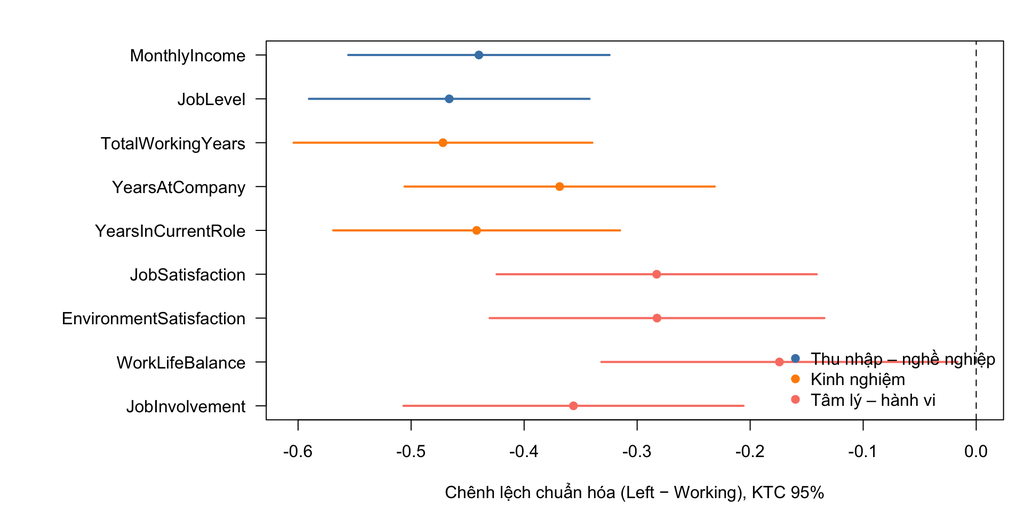

```r
# Chênh lệch chuẩn hóa (Left − Working)/s_gộp với khoảng tin cậy 95%, để so sánh 9 biến trên cùng thang
s_gop <- sapply(bien, function(v) {
  y <- ea[[v]]; sqrt(((n1 - 1) * var(y[nhom == "No"]) + (n2 - 1) * var(y[nhom == "Yes"])) / (n - 2))
})
d_cd   <- tung_bien$chenh / s_gop
d_duoi <- tung_bien$ci_duoi / s_gop
d_tren <- tung_bien$ci_tren / s_gop
mau <- rep(c("steelblue", "darkorange", "salmon"), times = lengths(khoi))
par(mar = c(4.5, 13, 2, 1))
plot(d_cd, 9:1, xlim = range(c(d_duoi, d_tren, 0)), pch = 19, col = mau, yaxt = "n",
     xlab = "Chênh lệch chuẩn hóa (Left − Working), KTC 95%", ylab = "", main = "")
segments(d_duoi, 9:1, d_tren, 9:1, col = mau, lwd = 2)
axis(2, at = 9:1, labels = bien, las = 1)
abline(v = 0, lty = 2)
legend("bottomright", legend = names(khoi), col = c("steelblue", "darkorange", "salmon"), pch = 19, bty = "n")
```

Trên cùng thang độ lệch chuẩn, khác biệt lớn nhất ở `TotalWorkingYears` và `JobLevel` (khoảng −0.47), nhỏ nhất ở `WorkLifeBalance` (−0.17, khoảng tin cậy sát 0); các biến thu nhập – nghề nghiệp và kinh nghiệm nằm xa 0 hơn các biến tâm lý – hành vi.

## 5.4 Kịch bản 2: bỏ MonthlyIncome (8 biến)

Khi bỏ `MonthlyIncome` (kịch bản 2 ở mục 3, 4), các kiểm định từng biến của 8 biến còn lại giữ nguyên thống kê và p-giá trị gốc, chỉ có hai thay đổi: khối thu nhập – nghề nghiệp chỉ còn `JobLevel` nên MANOVA của khối trở thành ANOVA một biến ($p_k = 1$, Pillai $= SSB/SST$), và hiệu chỉnh Holm thực hiện qua $m = 8$ biến thay vì 9.

```r
khoi_kb2 <- khoi; khoi_kb2[["Thu nhập – nghề nghiệp"]] <- "JobLevel"
set.seed(2026)
manova_khoi_kb2 <- do.call(rbind, lapply(names(khoi_kb2), function(k) {
  M  <- X[, khoi_kb2[[k]], drop = FALSE]
  st <- pillai_tq(M, nhom)
  v  <- pillai_bootstrap(M, nhom)
  data.frame(khoi = k, p_k = ncol(M), Pillai = st[1], F = st[2], df1 = st[3], df2 = st[4], p = st[5],
             p_bootstrap = (sum(v >= st[1]) + 1) / (B_lan + 1))
}))
manova_khoi_kb2$p_holm <- p.adjust(manova_khoi_kb2$p, method = "holm")
bang(transform(manova_khoi_kb2, p = fp(p), p_holm = fp(p_holm)), digits = 4, row.names = FALSE,
     col.names = c("Khối biến", "Số biến", "Pillai V", "F", "df1", "df2", "p-giá trị", "p bootstrap", "p Holm"),
     caption = "Kịch bản 2: MANOVA theo khối")
```

Kịch bản 2: MANOVA theo khối

| Khối biến | Số biến | Pillai V | F | df1 | df2 | p-giá trị | p bootstrap | p Holm |
| --- | --- | --- | --- | --- | --- | --- | --- | --- |
| Thu nhập – nghề nghiệp | 1 | 0.0286 | 43.2153 | 1 | 1468 | 6.8e-11 | 0.001 | 6.8e-11 |
| Kinh nghiệm | 3 | 0.0392 | 19.9431 | 3 | 1466 | 1.14e-12 | 0.001 | 2.27e-12 |
| Tâm lý – hành vi | 4 | 0.0435 | 16.6594 | 4 | 1465 | 2.32e-13 | 0.001 | 6.97e-13 |

Khối thu nhập – nghề nghiệp chỉ còn `JobLevel`: Pillai = 0.0286, F(1, 1468) = 43.22, p-giá trị Holm = 6.8e-11 < 0.05 (p bootstrap = 0.001), nên ta bác bỏ $H_0$ với mức ý nghĩa 5%, nghĩa là cấp bậc trung bình của hai nhóm khác nhau. Pillai bằng kịch bản 1 (0.0286 khi có cả thu nhập và cấp bậc): `JobLevel` một mình phân biệt hai nhóm như cả khối, nên `MonthlyIncome` không thêm thông tin. Hai khối còn lại không đổi; cả 3 khối vẫn có p-giá trị Holm < 0.05.

```r
tb_kb2 <- tung_bien[tung_bien$bien != "MonthlyIncome", ]
bang(data.frame(bien = tb_kb2$bien,
                p_welch_9 = fp(tb_kb2$p_welch_holm), p_welch_8 = fp(p.adjust(tb_kb2$p_welch, method = "holm")),
                p_mw_9 = fp(tb_kb2$p_mw_holm), p_mw_8 = fp(p.adjust(tb_kb2$p_mw, method = "holm"))),
     row.names = FALSE, col.names = c("Biến", "m = 9", "m = 8", "m = 9", "m = 8"),
     caption = "p-giá trị Holm theo số biến hiệu chỉnh") |>
  them_tieu_de(header = c(" " = 1, "Welch t" = 2, "Mann-Whitney" = 2))
```

p-giá trị Holm theo số biến hiệu chỉnh

| Biến | m = 9 | m = 8 | m = 9 | m = 8 |
| --- | --- | --- | --- | --- |
| JobLevel | 7.88e-12 | 7.88e-12 | 2.04e-12 | 2.04e-12 |
| TotalWorkingYears | 8.12e-11 | 8.12e-11 | 2.16e-13 | 1.92e-13 |
| YearsAtCompany | 1.14e-06 | 1.14e-06 | 2.04e-12 | 2.04e-12 |
| YearsInCurrentRole | 1.91e-10 | 1.91e-10 | 2.21e-11 | 2.21e-11 |
| JobSatisfaction | 0.000316 | 0.000316 | 0.000239 | 0.000239 |
| EnvironmentSatisfaction | 0.000418 | 0.000418 | 0.000435 | 0.000435 |
| WorkLifeBalance | 0.0305 | 0.0305 | 0.0465 | 0.0465 |
| JobInvolvement | 1.87e-05 | 1.87e-05 | 1.86e-05 | 1.86e-05 |

Với $m = 8$, p-giá trị Holm của Welch t không đổi ở cả 8 biến và của Mann-Whitney chỉ đổi ở `TotalWorkingYears` (2.16e-13 thành 1.92e-13), vì Holm nhân p-giá trị xếp thứ $k$ với $m - k + 1$: bỏ một biến làm $m$ giảm 1 và thứ hạng của các biến xếp sau nó cũng giảm 1, nên hệ số nhân của chúng giữ nguyên; chỉ biến xếp trước `MonthlyIncome` (ở Mann-Whitney là `TotalWorkingYears`, xếp thứ nhất) có hệ số nhân giảm từ 9 xuống 8. Cả 8 biến vẫn có p-giá trị Holm < 0.05, nên ta bác bỏ $H_0$ với mức ý nghĩa 5% cho cả 8 biến; kết luận của mục này không phụ thuộc vào việc giữ hay bỏ `MonthlyIncome`.

## 5.5 Kết luận

Với mức ý nghĩa 5%, sau hiệu chỉnh Holm:

1. Cả **3 khối biến** đều có khác biệt đa biến giữa nhân viên đã nghỉ việc và nhân viên đang làm việc (MANOVA theo khối và bootstrap trong từng nhóm đều cho p-giá trị < 0.05).
2. Cả **9 biến** đều có khác biệt đáng kể: nhân viên đã nghỉ việc có thu nhập, cấp bậc, tổng số năm làm việc, số năm tại công ty, số năm ở vị trí hiện tại và 4 mức hài lòng – tham gia **thấp hơn** nhân viên đang làm việc. Kết luận giống nhau ở ANOVA, Welch t và Mann-Whitney, nên không phụ thuộc vào giả định chuẩn hay phương sai bằng nhau.
3. Khác biệt rõ nhất ở **kinh nghiệm và thu nhập – cấp bậc**; yếu nhất ở **cân bằng công việc – cuộc sống**. Độ lớn ảnh hưởng của từng biến đều nhỏ ($\omega^2 < 0.03$), phù hợp với kết quả mục 4 là hai nhóm chồng lấn nhiều.

# 6 Nhận xét và ý nghĩa thực tiễn

## 6.1 Hồ sơ hai nhóm nhân viên

Bảng dưới tóm tắt khác biệt giữa nhân viên đang làm việc (Working) và đã nghỉ việc (Left) từ các mục 4–5: trung bình mỗi nhóm, chênh lệch chuẩn hóa $d = (\bar x_{Left} - \bar x_{Working})/s_{gộp}$ (mục 3) và độ lớn ảnh hưởng $\omega^2$ (mục 5).

```r
khoi_cua_bien <- c(rep("Thu nhập – nghề nghiệp", 2), rep("Kinh nghiệm", 3), rep("Tâm lý – hành vi", 4))
ho_so <- do.call(rbind, lapply(bien, function(v) {
  y <- ea[[v]]; y1 <- y[nhom == "No"]; y2 <- y[nhom == "Yes"]
  s_gop <- sqrt(((n1 - 1) * var(y1) + (n2 - 1) * var(y2)) / (n - 2))
  a <- anova(lm(y ~ nhom)); ss <- a$`Sum Sq`; ms <- a$`Mean Sq`
  data.frame(bien = v, tb_Working = mean(y1), tb_Left = mean(y2),
             chenh_pct = (mean(y2) - mean(y1)) / mean(y1) * 100,
             d = (mean(y2) - mean(y1)) / s_gop,
             omega2 = (ss[1] - a$Df[1] * ms[2]) / (sum(ss) + ms[2]))
}))
bang(cbind(khoi = khoi_cua_bien, ho_so), digits = 3, row.names = FALSE,
     col.names = c("Khối", "Biến", "Working", "Left", "Chênh lệch (%)", "d", "ω²")) |>
  them_tieu_de(header = c(" " = 2, "Trung bình" = 2, " " = 3)) |>
  gop_dong(cot = 1)
```

| Khối | Biến | Working | Left | Chênh lệch (%) | d | ω² |
| --- | --- | --- | --- | --- | --- | --- |
| Thu nhập – nghề nghiệp | MonthlyIncome | 6832.740 | 4787.093 | -29.939 | -0.440 | 0.025 |
| Thu nhập – nghề nghiệp | JobLevel | 2.146 | 1.637 | -23.712 | -0.466 | 0.028 |
| Kinh nghiệm | TotalWorkingYears | 11.863 | 8.245 | -30.500 | -0.472 | 0.029 |
| Kinh nghiệm | YearsAtCompany | 7.369 | 5.131 | -30.373 | -0.369 | 0.017 |
| Kinh nghiệm | YearsInCurrentRole | 4.484 | 2.903 | -35.262 | -0.442 | 0.025 |
| Tâm lý – hành vi | JobSatisfaction | 2.779 | 2.468 | -11.165 | -0.283 | 0.010 |
| Tâm lý – hành vi | EnvironmentSatisfaction | 2.771 | 2.464 | -11.083 | -0.282 | 0.010 |
| Tâm lý – hành vi | WorkLifeBalance | 2.781 | 2.658 | -4.415 | -0.174 | 0.003 |
| Tâm lý – hành vi | JobInvolvement | 2.770 | 2.519 | -9.078 | -0.356 | 0.016 |

Nhóm Left thấp hơn ở cả 9 biến: thu nhập và các biến kinh nghiệm thấp hơn 24–35%, các biến tâm lý – hành vi thấp hơn 4–11%. Theo $d$ và $\omega^2$, khác biệt lớn nhất ở kinh nghiệm và thu nhập – nghề nghiệp ($|d|$ 0.37–0.47), nhỏ nhất ở `WorkLifeBalance` ($d = -0.17$, $\omega^2 = 0.003$).

Để đọc khác biệt theo góc nhìn quản trị, bảng dưới cho **tỷ lệ nghỉ việc** (%) theo các mức của những biến khác biệt rõ nhất. Tỷ lệ nghỉ việc chung của công ty là 16.1%.

```r
ty_le_nghi <- function(x) round(tapply(nhom == "Yes", x, mean) * 100, 1)
nhom_tham_nien <- cut(ea$YearsAtCompany, c(-1, 2, 5, 10, 40), labels = c("0–2 năm", "3–5 năm", "6–10 năm", "> 10 năm"))

bang(data.frame(JobLevel = names(ty_le_nghi(ea$JobLevel)), so_nv = as.vector(table(ea$JobLevel)),
                ty_le = ty_le_nghi(ea$JobLevel)), row.names = FALSE,
     col.names = c("Cấp bậc", "Số nhân viên", "Tỷ lệ nghỉ việc (%)"))
```

| Cấp bậc | Số nhân viên | Tỷ lệ nghỉ việc (%) |
| --- | --- | --- |
| 1 | 543 | 26.3 |
| 2 | 534 | 9.7 |
| 3 | 218 | 14.7 |
| 4 | 106 | 4.7 |
| 5 | 69 | 7.2 |

Tỷ lệ nghỉ việc ở cấp 1 (26.3%) cao gần gấp đôi tỷ lệ chung; từ cấp 2 trở lên chỉ còn 4.7–14.7%.

```r
bang(data.frame(tham_nien = levels(nhom_tham_nien), so_nv = as.vector(table(nhom_tham_nien)),
                ty_le = ty_le_nghi(nhom_tham_nien)), row.names = FALSE,
     col.names = c("Số năm tại công ty", "Số nhân viên", "Tỷ lệ nghỉ việc (%)"))
```

| Số năm tại công ty | Số nhân viên | Tỷ lệ nghỉ việc (%) |
| --- | --- | --- |
| 0–2 năm | 342 | 29.8 |
| 3–5 năm | 434 | 13.8 |
| 6–10 năm | 448 | 12.3 |
| > 10 năm | 246 | 8.1 |

Tỷ lệ nghỉ việc giảm dần theo thâm niên: 29.8% ở nhóm 0–2 năm, xuống còn 8.1% ở nhóm trên 10 năm.

```r
tl_tam_ly <- t(sapply(bien_tl, function(v) ty_le_nghi(ea[[v]])))
bang(tl_tam_ly, col.names = c("Mức 1", "Mức 2", "Mức 3", "Mức 4"),
     caption = "Tỷ lệ nghỉ việc (%) theo mức của 4 biến tâm lý – hành vi (1 = thấp nhất)")
```

Tỷ lệ nghỉ việc (%) theo mức của 4 biến tâm lý – hành vi (1 = thấp nhất)

|  | Mức 1 | Mức 2 | Mức 3 | Mức 4 |
| --- | --- | --- | --- | --- |
| JobSatisfaction | 22.8 | 16.4 | 16.5 | 11.3 |
| EnvironmentSatisfaction | 25.4 | 15.0 | 13.7 | 13.5 |
| WorkLifeBalance | 31.2 | 16.9 | 14.2 | 17.6 |
| JobInvolvement | 33.7 | 18.9 | 14.4 | 9.0 |

Ở cả 4 thang, nhân viên chọn mức 1 có tỷ lệ nghỉ việc cao nhất (22.8–33.7%); với `EnvironmentSatisfaction` và `JobInvolvement`, tỷ lệ giảm dần khi mức tăng.